# 智能制造系统设计 · 第 8 讲：工程与社会与工程伦理（一）工程事故与伦理准则

刘训臣

山东科技大学 机械电子工程学院

# 第〇部分 · 课程介绍与本讲定位

- 教学内容与主线：工程的社会性 → 凯悦事故完整剖析 → 职业伦理准则 → 伦理决策框架
- **本讲是伦理专题的第一讲**：把前七个技术模块，收到“人”和“责任”上
- 四个内容块各配可核查的案例，事实到时间、地点、伤亡、责任判定、后果
- 落点：工程师在组织与公众之间，凭什么判断、凭什么叫停

## 第 8 讲：教学内容与主线（一）

**内容块 1 · 工程的社会性与事故代价**

- 工程是人为创造的世界，错误与失败如影随形
- 工程师的三重职责：安全性、经济性、可操作程度
- 事故的社会代价：生命、财产、职业、制度

**内容块 2 · 凯悦酒店天桥坍塌案例**

- 1981 年 7 月 17 日，堪萨斯城，114 人死亡、216 人受伤
- 连接处设计变更 → 荷载翻倍 → 复核缺位 → 连续倒塌
- 后果：工程师吊销执照、公司剥夺资质、约 1.4 亿美元赔偿

## 第 8 讲：教学内容与主线（二）

**内容块 3 · 工程师职业伦理准则**

- NSPE 准则：总则、六条基本准则、执业规则
- 中国机械工程师职业道德规范、台湾工程师信条
- 切尔诺贝利：设计缺陷、操作失误与刻意隐瞒

**内容块 4 · 伦理决策框架与案例**

- 后果论、义务论、美德伦理
- 挑战者号、Citicorp 大楼、波音 737 MAX
- 组织压力下的判断与责任边界

## 教学进度 · 10 次课全览

| 次 | 模块 | 主题 |
| --- | --- | --- |
| 1 | 导论与 3.1 | 课程导论、工程与社会与质量工程（一）：国家战略、工程的社会属性、质量管理基础 |
| 2 | 3.1 | 质量工程（二）与质量工具：五大工具 APQP／FMEA／MSA／SPC／PPAP、CPK、QC 七大手法 |
| 3 | 3.2 | 工业工程与精益生产（＋实验 2 课时：线性规划与工业工程例子） |
| 4 | 3.3、3.4 | 安全工程与环保工程：海因里希法则、事故树 FTA、风险评估、三废治理、双碳 |
| 5 | 3.5、3.6 | 成本管理与人力资源：成本构成、投资回收期、NPV／IRR、质量成本、人才与激励 |
| 6 | 4.1～4.3 | 企业信息系统（一）：ERP、MES、PLM 与系统集成全景 |
| 7 | 4、6 | 企业信息系统（二）与 8D：CRM／WMS／APS，8D 八步与软件开发流程 |
| **8** | **工程伦理（一）** | **工程事故与伦理准则：凯悦酒店、NSPE 准则、伦理决策框架** |
| 9 | 工程伦理（二） | 风险、安全与责任，工程师与组织：责任判定、组织文化与信任 |
| 10 | 伦理（三）与综合 | 技术的社会意义、国际化、AI 伦理；智能设计应用、前沿、课程设计与总复习 |

## 本讲在课程中的位置

**前面七讲**解决“把事做对”：质量工具、工业工程、安全与环保、成本、信息系统、8D。

**本讲**解决“做对的事”：

- 前七讲的工具都是**手段**，本讲问的是**目的**与**边界**
- 质量工具（FMEA）是对失效后果的**预见责任**，本讲把“预见”变成可判定的准则
- 8D 的 D7“预防再发”是**责任闭环**，本讲讲闭环失效时会发生什么

**后面**：第 9 讲风险与组织，第 10 讲把三讲汇总为课程设计的三步伦理分析框架。

- 工程与社会与工程伦理专题共 **6 课时**：本讲为伦理专题的**第 2–3 课时**（第 1 讲 1 ＋ 第 8 讲 2 ＋ 第 9 讲 2 ＋ 第 10 讲 1）

> 一句话：**技术能力决定你能不能做，伦理判断决定你该不该做。**

## 工程与社会与工程伦理 · 6 课时分布

| 讲 | 伦理课时 | 主题 | 伦理课时序号 |
| --- | --- | --- | --- |
| 1 | 1（内容块 2、4） | 工程与社会导论；质量的社会责任与伦理主线 | 第 1 课时 |
| 8 | 2 | 工程事故与伦理准则（凯悦案例、NSPE 准则、决策框架） | 第 2–3 课时 |
| 9 | 2 | 风险、安全与责任，工程师与组织（组织文化、信任） | 第 4–5 课时 |
| 10 | 1（内容块 1–2） | 技术的社会意义、国际化、AI 伦理 → 三步分析框架 | 第 6 课时 |

- 合计 **6 课时**（全课 22 课时 = 10 次课 20 课时 ＋ 实验 2 课时）
- 此外，伦理问题以前七讲「伦理与社会落点」形式贯穿：每次课留 5–10 分钟讨论

## 本讲的两个落点

**落点一：事故是可以用工程语言拆开的**

- 时间、结构、荷载、变更、复核、裁决，全都有据可查
- 拆开之后，责任不是“感觉”，而是**可指认的节点**
- 与本课程的工具对应：FTA 找最小割集、FMEA 找失效模式、8D 找根因

**落点二：准则与框架是给“不敢说”的人用的**

- 准则给判据，框架给说理，两者配合才能对上级说“不”
- 三个案例（凯悦、挑战者号、737 MAX）都是“组织压力压过工程判断”
- 本讲的作业与考试题都要求：**先给事实，再给判断，最后给依据**

## 本讲 90 分钟怎么安排

> **六个时间块 6＋22＋18＋22＋18＋4＝90 分钟，一分钟机动都没有。**

| 序 | 时间块 | 讲什么 | 分钟 |
| --- | --- | --- | --- |
| 0 | 开场与回顾 | 六问、目标、路线图 | 6 |
| 1 | 工程的社会性与代价 | 三重职责、四维代价 | 22 |
| 2 | 凯悦酒店天桥坍塌 | 变更→荷载翻倍→责任 | 18 |
| 3 | 工程师职业伦理准则 | NSPE 六条、三套准则 | 22 |
| 4 | 伦理决策框架与案例 | 三框架与三家事故 | 18 |
| 5 | 收尾 | 考法、小结、作业 | 4 |

- 两个 22 分钟给概念（社会性、准则），两个 18 分钟给案例（凯悦、三家事故）
- 案例合计 36 分钟，是全场重心：事实链讲不清，三框架就悬空
- 156 页 90 分钟，每页 35 秒：讲判据与事实链，不逐条念准则
- 先压切尔诺贝利细节与条款宣读；凯悦荷载、NSPE 六条、三框架不能压
- 收尾 4 分钟只做三件事：点一页考法、三句话小结、作业与预告

## 第 7 讲回顾与检查：六个问题

> **六问各 30 秒：答不出的那一条，就是今天要接的那一条。**

| 概念 | 一句话答案 | 今天怎么接 |
| --- | --- | --- |
| ① CRM | 战略理念与系统：分层、漏斗、服务 | 客户承诺就是责任起点 |
| ② RFM | R、F、M 三维，阈值先声明 | 指标设在哪，动作就长在哪 |
| ③ WMS | 六段作业加策略，账实相符 | 数据不准是伦理问题第一现场 |
| ④ APS | 四类约束下做有限产能排程 | 交期与安全冲突时谁优先 |
| ⑤ 8D | D4 真因、D7 修订、D8 签字 | 今天讲闭环为什么会失效 |
| ⑥ 软件开发 | 调研→蓝图→实施→上线→改进 | “先上线再补测试”的压力 |

- 六问分三类：①② 靠说清概念，③④ 靠算与判，⑤⑥ 靠流程
- 抽查方式：合上讲义写关键词，随机点两人各答一问，答不出不扣分
- 一句提醒：第 7 讲 D8 的签字即责任，就是今天凯悦案的入口

## 本讲学习目标与能力清单

> **四条能力＝四个动作：会判、会引、会推、会写。**

| 能力 | 具体要求与落点 | 验收标准（可检查） |
| --- | --- | --- |
| 会判责任 | 四类责任：因果、角色、法律、道德；内容块 1、2 | 在凯悦事故链上标出三处可拦截点 |
| 会用准则 | NSPE 六条基本准则与四条关键条款；内容块 3 | 5 个行为 3 分钟内匹配到条款 |
| 会做推理 | 后果论、义务论、美德伦理三栏分析；内容块 4 | 写出三栏并指出框架冲突处 |
| 会写案例 | 事实→可预见→准则→结论 四段式；内容块 4 与作业 | 300 字，按四段给分自评达标 |

- 四个动词：判、引、推、写；不要求背伦理学史与人名年代
- 与前七讲衔接：FMEA 练“预见”，8D 练“闭环”，本讲练“该不该”与“谁负责”
- 验收都写成当场能做的动作，不写“理解”“掌握”
- 作业即课程设计伦理章的底稿，从现在开始攒案例

## 伦理专题三讲地图

> **一条线：先给准则（第 8 讲），再进组织（第 9 讲），最后放到社会与全球（第 10 讲）。**

| 讲 | 一句话问题 | 核心工具 | 主案例 |
| --- | --- | --- | --- |
| 8（本讲） | 对谁负责、凭什么判断 | 事故链、准则、三框架 | 凯悦、挑战者号、737 MAX |
| 9 | 风险多大、责任怎么定 | 风险公式、FTA 与 ETA、判定四问 | 7·23、凤凰沱江桥、吹哨人 |
| 10 | 技术如何嵌入社会 | 三步框架、跨文化、AI 治理 | 华盛顿协议、跨国工程、算法招聘 |

- 第 8 讲给依据，第 9 讲给程序，第 10 讲给框架：缺一环，案例就写不完整
- 案例分工不重复：本讲用国外经典，第 9 讲用国内事故与组织，第 10 讲用国际与 AI
- 本讲是三讲的地基：准则记不住，第 9 讲的“责任判定四问”就没有依据
- 第 9 讲先埋一个词：责任模糊化——组织让“谁负责”变得说不清
- 第 10 讲只有 1 课时（内容块 1–2）讲伦理，其余给智能设计与总复习，三步框架要当堂记

## 考试视角：伦理在本课程怎么考

> **六卷没有一道伦理题；但“结合案例谈责任”的题，随时可能出。**

| 考查形态 | 分值 | 六卷实况（2020 至 2022） | 怎么准备 |
| --- | --- | --- | --- |
| 直接伦理题 | 0 分 | 六卷均未单独命题 | 不押题，但要写得出 |
| 三道大题 | 3×10 分 | 矩阵、事故树、鱼骨图 | 鱼骨图“人”“法”两支是入口 |
| 预测题 | 按 10 分估 | 结合凯悦或 737 MAX 谈责任 | 事实→可预见→准则→结论 |
| 计算题 | 10 分 | 静态投资回收期 | 与伦理无关，不占复习时间 |

- 卷面结构：单选 30＋简答 30＋三道大题 30＋计算 10，伦理没有独立分值
- 伦理分藏在“分析原因”“谁该负责”的追问里：有事实、有判据才给分
- 预测题按 12 分钟、300 到 400 字准备：四段各一段，先依据后结论
- 提醒：写“我认为”之前，先写依据（如 NSPE II.1.b：只批准合规文件）

## 本讲路线图与课前准备

> **一条主线：看见代价 → 拆开事故 → 拿到准则 → 学会推理 → 带走方法。**

| 部分 | 分钟 | 入口问题 | 出口 |
| --- | --- | --- | --- |
| 〇 开场 | 6 | 第 7 讲留下什么 | 六问过关、目标清楚 |
| 一 社会性 | 22 | 工程为何天生有风险 | 说清三重职责与四维代价 |
| 二 凯悦 | 18 | 变更怎么变成灾难 | 指认责任节点与依据 |
| 三 准则 | 22 | 凭什么对上级说“不” | 背六条、会匹配条款 |
| 四 框架 | 18 | 三种框架怎么用 | 三栏分析加四段结论 |
| 五 收尾 | 4 | 带走什么 | 作业清楚、预告明确 |

- 课前读：教材 1.5 与 1.6 节（工程作为专业、伦理的三个层次）、案例 17
- 必带：讲义、计算器（例题 1 要算安全系数）、第 7 讲 8D 报告草稿
- 预习问题：凯悦的吊杆变更送到你桌上，你至少要哪三样东西才敢签字
- 纪律：案例的时间、伤亡、判决会进考试，课上跟事实链，不抄 PPT

## 推导留给 AI：课程定位与本讲主线（汇总）

- 用一句话把“工程作为社会实验”与“工程师对可预见后果负责”连起来，中间缺哪一环？
- 本讲四个内容块分别回答哪一个问题？如果调换顺序，哪一处会讲不通？
- 为什么伦理专题放在七讲技术之后而不是第一讲？换成第一讲会失去什么？
- 把“技术能力决定你能不能做，伦理判断决定你该不该做”改写成一个可操作的判定流程。

## 产教融合 · 本讲企业真题：从凯悦酒店到齿轮产线的责任链

> **企业场景：**凯悦酒店天桥 1981 年坍塌致 114 人死亡；企业齿轮线也发生过防护罩缺失下的灼伤未遂，责任在操作工、班组长还是设计者？

| 企业真实问题 | 本讲工具 | 学生产出 |
| --- | --- | --- |
| 设计变更、复核缺失与责任模糊，事故代价由谁承担 | NSPE 伦理准则、伦理决策框架、利益相关方分析 | 责任链分析＋备选方案与辩护 |

- **教案对应：**第三章 3.3 安全工程、第六章 8D；**企业参与：**企业安环部提供事故与隐患记录（脱敏）
- **验收：**事实准确；能区分直接责任、管理责任与设计责任；备选方案能回应反对意见。

# 第一部分 · 工程的社会性与事故代价

- 工程是人造的世界：错误与失败与人类活动如影随形
- 工程师的三重职责：安全性、经济性、可操作程度
- 工程作为社会实验：三种不确定性决定责任边界
- 事故代价的四层：生命、家庭、社区、信任，并沿责任链追问“谁签章、谁把关”

## 工程伦理为什么不同于普通职业道德

普通的职业道德——诚实、勤勉、守约、保密——任何行业都要讲；工程伦理多出四层：

1. **公众安全优先**：服务对象不只是雇主，还有**不特定的公众**与未来使用者（NSPE 第一条）
2. **知识不对称**：委托人与公众看不懂工程师的判断，只能依赖信任——所以必须主动披露
3. **风险不可逆**：医生面对一个病人，工程师面对成千上万的陌生人；一次失误无法“重做实验”
4. **责任链长**：设计—采购—施工—运维—监管，责任沿链条分散，容易被模糊化
- 对照：医生有个体知情同意，律师有当事人保密；工程师面对的是**不在场的第三方**
- 结论：工程伦理不是把普通道德放大，而是增加了**对不特定第三方的义务**

## 工程的社会性：技术决策的社会后果

- **工程**：用数学与自然科学知识经济地利用自然之力，为人类造福
- 工程嵌在社会里：物、知识、人、组织、监管者共同构成技术
- 每个技术决策都在**分配风险与收益**：选材、定公差、改工艺等于定谁承担
- 737 MAX 停飞：CFM 每月损失约 1 亿欧元，美国制造业一月少 1.2 万岗
- 判据：看不全后果，但必须看清并说出**可预见的那一段**

## 工程的六大特征：社会性不是第六项

- 回顾第 1 讲：目的性、约束性、综合性、创造性、风险性、社会性

| 特征 | 一句话 | 社会性落在哪 |
| --- | --- | --- |
| 目的性 | 从需求出发 | 需求由谁定义、为谁服务 |
| 约束性 | 成本、工期、法规 | 约束是社会谈判的结果 |
| 综合性 | 多学科、多利益方 | 协调的其实是人 |
| 创造性 | 没有现成答案 | 新方案要被社会接受 |
| 风险性 | 一次性、难预演 | 风险由不特定的人承担 |
| 社会性 | 嵌在社会之中 | 前五项的总和 |

- 深化：社会性不是并列的第六项，而是**穿过前五项的一条线**
- 判据：对任一特征追问“谁受益、谁承担、谁同意”，就回到了社会性

## 工程作为社会实验：三要素与伦理含义

- 教材 4.1 引 Martin 与 Schinzinger：工程是**社会实验**，与科学实验三点相通
1. **实验对象**：使用工程产品的公众，就是被试
2. **结果不确定**：新车在路上的表现、新楼抗不抗台风，事前无法确知
3. **实验者负责**：工程师必须预想好坏两种后果，并尽量消除坏后果
- 与科学实验的关键差别：被试**不知情、未同意、无法退出**
- 不确定性三类：**技术**（模型简化、材料性能、荷载假设）、**人为**（沟通、操作、复核、变更）、**外部**（环境、灾害、不可抗力）——凯悦案三者各占一条
- 伦理含义四条：知情同意、可退出、运行期监督、出错后补偿
- 一句话：实验可以失败，但**不能在被试不知情时失败**

## 科学、技术、工程：三种责任边界

| 维度 | 科学 | 技术 | 工程 |
| --- | --- | --- | --- |
| 责任对象 | 知识共同体 | 使用者与标准 | 不特定的公众 |
| 时间尺度 | 长期，可修正 | 中期，可迭代 | 一次建成，难回头 |
| 失败后果 | 可重做实验 | 可召回、可替换 | 不可逆 |
| 评价标准 | 真假与解释力 | 有效、经济 | 安全、可接受 |

- 责任差异的根源是**可重复性**：科学实验能重做，工程失败不能重来
- 科学家的责任止于共同体检验，工程师的责任延伸到**不在场的人**
- 技术的责任落在标准与召回，工程的责任落在**签章与最终把关**
- 一句话：**科学无禁区，研究有纪律，应用有禁忌**；科学问“是不是真的”，工程问“出事谁负责”

## 工程师的多重角色与各自的义务

| 角色 | 核心义务 | 典型冲突 | 失守后果 |
| --- | --- | --- | --- |
| 设计者 | 安全余量、可施工 | 工期与成本 | 凯悦连接处 |
| 研究者 | 数据真实、可复现 | 出成果的压力 | 编造与撤稿 |
| 管理者 | 资源、监督下属 | 指标与安全 | 总工未密切监督 |
| 评审者 | 独立判断、签章 | 人情与进度 | 盖章放行 |

- **三重职责**：**安全**（对使用者、操作者与公众）、**经济**（对雇主与客户的成本、工期与回报）、**可操作**（对施工、检验、维护的现实可行）；冲突时**安全优先**
- 一人常兼数角：上午设计、下午评审——**不能自己审自己**
- 工程师**串行**排序（安全是门槛），管理者**并列**权衡（全部摆上桌）（教材 7.7）
- 判据：分清这是 PED 还是 PMD，越界就是角色失守
- 角色越多，越要写清“这次我以什么身份签字”

## 工程共同体：谁对什么负责

- 香港工程师学会行为守则的四大责任：对专业、对同事、对雇主或客户、对公众（课件）

| 主体 | 对谁负责 | 凯悦案中的表现 |
| --- | --- | --- |
| 业主 | 投资人与住客 | 三次拒绝设现场设计代表 |
| 设计方 | 公众与规范 | 盖章放行变更、未追前兆 |
| 施工方 | 图纸与实物一致 | 提出变更、未特别标注 |
| 行业 | 职业标准 | 事后由 ASCE 改规则 |

- 多手问题：参与的人越多，越容易说“不是我一个人的责任”（教材 3.11）
- Larry May 的判据：责任大小 = 你本可合理阻止的程度
- 共同体的含义：**没有人能因“别人也有份”而免责**

## 事故的社会代价：生命、家庭、社区、信任

| 层次 | 代价 | 凯悦案的证据 |
| --- | --- | --- |
| 生命 | 不可逆的死亡与伤残 | 114 死、216 伤，1981-07-17 |
| 家庭 | 上百个家庭失去亲人 | 民事赔偿约 1.4 亿美元 |
| 社区 | 集体记忆与地方认同 | 星报调查获普利策奖；2008 年纪念 |
| 信任 | 对职业与监管的信心 | ASCE 事后改结构责任规则 |

- 排序：生命不可逆，信任最难修——赔款可以计价，纪念不能
- 同一模板可跨案比较：凤凰沱江大桥（2007）64 死 22 伤；甬温线（2011）40 死 172 伤、直接损失约 1.94 亿元
- 四层代价里，只有前两层能进法庭，后两层只能进历史
- 代价有滞后性：纪律裁决与赔偿都在事故发生数年之后
- 代价还会转成制度成本：规范、审查与保险条款随之改写

## 工程失败的四类：技术、管理、组织、伦理

| 类型 | 典型机制 | 凯悦案对应 | 可拦截点 |
| --- | --- | --- | --- |
| 技术 | 承载力不足、工况漏算 | 133 kN 对 178 kN | 复核计算 |
| 管理 | 变更无评审、压工期 | 电话同意即改图 | 变更单与评审 |
| 组织 | 责任分散、范围受限 | 只查屋顶、拒绝现场代表 | 独立审查与授权 |
| 伦理 | 知情不报、过度信任 | 图纸盖章放行 | 披露与追问 |

- 四类不互斥：一次事故通常四层同时有缺口
- 责任边界＝**可预见 × 可控制**：可预见的远近取决于工程师的知识与经验，可控制指他能左右的决策与结果
- 三道防线（设计复核、现场监督、独立第三方审查）任何一道有效都能拦住凯悦；FTA 语言：最小割集里有三个基本事件同时发生
- 只补技术层（加强计算）不动组织层（审查范围），同类事故还会来
- 分类的用处：先定位缺口层级，再决定改计算、改变更流程还是改授权
- 定位顺序：先看组织层（谁有权、谁被挡），再落到技术与个人

## 事故为何重复：六种学习失灵

1. **认识论**：故障树只估已识别的失效模式，未识别的模式不进估算，风险被系统性低估（教材 6.5）
2. **系统**：紧密耦合加复杂交互，小故障迅速扩散，Perrow 称之为“正常事故”
3. **记忆**：人走、项目结、文档散，教训随组织记忆一起流失
4. **成本**：安全投入在事故后上升，随记忆淡化被逐项削回
5. **归因**：把系统缺口归为“个别员工违章”，整改停在个人
6. **形式**：整改报告写完即结案，机制没有变
- 六种的共同点：**都在组织层，不在个人层**
- 判据：事故一年后，哪一条制度真的变了？

## 安全文化：报告文化与惩罚文化

- 教材 7.6 引 Hitachi 研究：组织文化分三类——工程师导向、客户导向、财务导向
- 财务导向的公司里，工程师被当成“参谋”，安全与质量最容易被压

| 维度 | 报告文化 | 惩罚文化 |
| --- | --- | --- |
| 坏消息 | 鼓励上报、有正式渠道 | 谁报谁倒霉 |
| 批评 | 对事不对人 | 追动机、查立场 |
| 记录 | 书面留痕、可追溯 | 口头传达、无记录 |
| 分歧 | 外部中立者、防报复 | 内部消化、拖延处理 |

- 报告文化不是态度，是**制度**：渠道、记录、中立、保护、时限，五件都要有
- 惩罚文化的代价：坏消息不上行，等它上行时已经是事故

## 职业的信任基础：隐含契约与诚实

- 信任不是感情，是**知识不对称下的理性选择**：委托人看不懂，只能信
- 隐含契约三方：工程师、雇主或客户、公众，其中公众最脆弱
- 契约的效益主义解读：按“能否给最多的人带来最大好处”作判断——但设计本身也可能**诱使**后续环节为方便而变更
- 信任靠四种诚实守住（教材 5.3 的四种不诚实，反过来即是）：不说谎、不蓄意欺骗、不隐瞒关键信息、不放弃查明真相
- 保密是义务，但有两种错法：不该说时说，该说时不说（教材 5.7）
- Davis：职业是**自愿承担法律与市场之外义务**的谋生方式
- 信任的脆弱：建十年，毁一次——凯悦图纸上的一枚印章，就是一次兑现或透支

## 工程师的公众责任：为不在场者说话

- 公众是谁：使用者、旁观者、未来使用者——都不在设计室里
- 三个不对称：信息、技术知识、时间，公众三项都缺
- 责任不是“别害人”，而是三个主动动作：**预见**、**告知**、**拒绝**
- 反例（教材 5.10）：1972 年 Convair 工程师 Dan Applegate 在备忘录里列出 DC-10 货舱门的危险，公司怕赔偿与诉讼，没有转告客户麦道
- 1974 年，该机型在巴黎奥利机场外坠毁，346 人全部遇难——备忘录写了，却没送到该送的人手里
- 判据：如果明天出事，我今天的记录能否证明我尽过告知义务？

## 利益相关者分析：权力与利益的矩阵

- 目的：把“公众”拆成具体的人，才知道该跟谁说、说多少

| 象限 | 判据 | 策略 |
| --- | --- | --- |
| 高权力、高利益 | 业主、监管 | 共同决策、书面确认 |
| 高权力、低利益 | 银行、保险 | 保持满意、定期通报 |
| 低权力、高利益 | 住客、周边居民 | 重点告知、代为发声 |
| 低权力、低利益 | 偶尔路过者 | 最低限度披露 |

- 凯悦案：住客与公众是“低权力、高利益”，在设计阶段没有入口
- 公正判据（课件）：收益与成本应在所有利益相关者之间公正分配
- 方法三步：列全名单、定象限、写明“谁代表沉默者”

## 价值冲突：效率、安全、成本、环境

| 冲突 | 工程表现 | 被牺牲的一方 | 判据 |
| --- | --- | --- | --- |
| 安全与成本 | 减薄、降规格 | 使用者 | 安全是门槛不是变量 |
| 效率与环境 | 产能与排放 | 周边社区 | 预防为主、可逆性 |
| 进度与质量 | 赶工、免检 | 施工与操作人员 | 串行排序 |
| 便利与隐私 | 过度采集 | 用户 | 知情同意 |

- 工程师的排序是**串行**：安全达标才谈成本；管理者的排序是**并列**：全部摆上桌（教材 7.7）
- 加权打分只用于“都已达标”的方案比较：$S=\sum_{i=1}^{n} w_i u_i$，且 $\sum_{i=1}^{n} w_i=1$
- 底线：不能把不可通约的东西（生命与利润）放进同一个加权和
- 把冲突公开化是第一步：被牺牲的一方要出现在会议记录里

## 工程伦理的三层次：微观、中观、宏观

| 层次 | 问题域 | 典型议题 | 主要责任者 |
| --- | --- | --- | --- |
| 微观 | 个人操守与判断 | 签字、披露、利益冲突 | 工程师个人 |
| 中观 | 组织与行业制度 | 变更控制、审查范围、准则 | 企业与职业团体 |
| 宏观 | 政策与社会选择 | 标准、监管、技术路线 | 政府与社会 |

- 三层不可互相替代：个人守规矩救不了坏制度，好制度也替不了个人判断
- 凯悦案三层同时失效：个人未复核、组织审查受限、规范与监管滞后
- 命名有争论：Herkert 二分（微观、宏观），Davis 主张三分（加中观）——分几层不重要，**别把系统问题个人化**
- 判据：先问“这是哪一层的问题”，再问“这一层谁有权改”

## 道德困境的六种类型

| 类型 | 冲突结构 | 例证 |
| --- | --- | --- |
| 利益冲突 | 私利与职务判断 | 礼品、关联供应商、兼职取酬 |
| 忠诚冲突 | 雇主与公众 | 凯悦、吹哨 |
| 诚实与保密 | 说与不说 | DC-10 备忘、商业机密 |
| 能力边界 | 接不接这活 | Brad：图纸未复核即盖章 |
| 组织不服从 | 服从还是阻止 | 拒签、越级上报 |
| 沉默的共谋 | 不作为也是选择 | 明知缺陷不追查 |

- 前三种是“两个义务打架”，后三种是“不作为也要负责”
- 判据：先把困境**命名**，再找准则条款，最后找可执行的第三条路
- 共同解法：把隐性冲突显性化，再走组织内的合法通道

## 从合规到负责：伦理的主动面

- 三个层次：守法（不违法）→ 守规（合标准）→ 负责（预想后果并主动行动）
- 合规的三个盲区：标准滞后于新技术；形式合规（材料齐、内容空）；责任分散（“大家都签了”）
- 教材 3.12：注意义务要求工程师意识到**现行规范可能不足**
- 负责的三个动作：**预演失败**、**留下证据**、**替沉默者说话**
- 詹天佑《敬告交通界青年工学家》：“学术虽精，道德不足，犹诸筑高屋于流沙之上，稍有震摇，无不倾倒。”
- 一句话：合规是别人给你的底线，负责是你给自己定的底线

## 汉莫拉比法典：最早的工程责任条款

[figure not shown]

- 约公元前 1772 年，古巴比伦第六代国王颁布，**282 条**，现存最早的系统法典
- 建造责任条款：
  - 房子倒塌致他人死亡 → 建造者**判死刑**
  - 致主人之子死亡 → 建造者之子**也要死**
  - 造成财产损坏 → 赔偿，并用**自己的财产**重建
  - 墙塌 → 自费修复
- 四千年前后的对照：凯悦案的工程师与公司**被剥夺执照与资质，但保留了生命**

## 从石柱到执照：责任形式的演变

| 阶段 | 责任形式 | 判定依据 | 典型后果 |
| --- | --- | --- | --- |
| 公元前 1772 年 | 同态复仇式人身责任 | 结果发生即责任 | 死刑、子女连坐 |
| 中世纪行会 | 行规与师徒制 | 手艺标准与行会规矩 | 逐出行会、失去营生 |
| 近代民法 | 过错责任 | 是否尽到注意义务 | 损害赔偿 |
| 现代职业制度 | 执照 + 职业准则 | 胜任、诚实、公众安全优先 | 吊销执照、剥夺资质、刑事责任 |

- 演变的主线：责任从“身体”转向“**资格与职业声誉**”
- 但内核未变：**建造者对其作品的安全负责**

## 案例导入：一根吊杆的变更

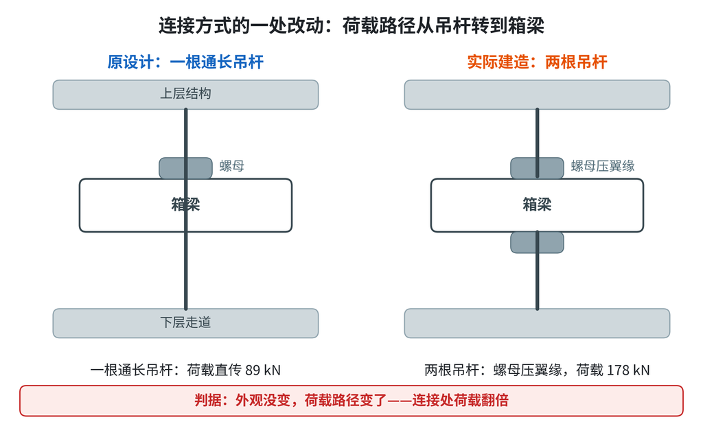

- 1981 年 7 月 17 日，堪萨斯城凯悦酒店中庭，两条悬挂走道先后坠落
- 原设计：一根通长吊杆穿过四楼箱梁，继续下伸吊住二楼走道
- 施工时施工方提出改法：两根吊杆各管一层，省去长吊杆穿两层走道的麻烦
- 变更没有回到计算，图纸盖着设计方的章，现场没有设计代表
- 四问留给下一部分：谁提出？谁知情？谁复核？谁承担后果？

## 本部分小结：从社会性到责任

- **社会性**：技术是系统，技术决策在分配风险与收益，后果沿供应链、就业与监管扩散
- **社会实验**：公众是被试，却不知情、未同意、难退出——所以责任必须前置
- **责任边界**：科学对知识负责，工程对后果负责；可重复性决定责任的分量
- **共同体**：多手不等于无责，责任跟着签章、授权与“本可阻止”走
- **代价**：生命不可逆、信任最难修；失败四类同现，学习六处失灵
- 一条主线：**社会性 → 代价 → 责任 → 主动负责**

## 本部分复习与练习

| 题型 | 题目 | 要点 |
| --- | --- | --- |
| 概念 | 社会实验三要素与四条伦理含义 | 被试、不确定、负责 |
| 概念 | 四类失败各举一个凯悦案的对应 | 一格一件事 |
| 计算 | 承载力 133 kN、荷载 178 kN，求安全系数 | $K=0.75$，维持 1.5 需 267 kN |
| 分析 | 用利益相关者矩阵列凯悦各方 | 标出“低权力高利益” |
| 辨析 | “符合规范就没有责任” | 规范可能不足 |
| 讨论 | 六个常见伦理问题各归微观、中观、宏观 | 说明理由 |

- 计算题要写公式与单位；分析题要能查到事实与条款
- 预习：第 9 讲风险来源（技术、人为、外部）与安全事故、安全责任事故之别

## 推导留给 AI：工程的社会性与事故代价（汇总）

- 用效益主义契约解释“工程师为什么必须为可预见的后果负责”，并给出一个它解释不了的反例。
- 若把责任定义为“可预见 × 可控制”，凯悦案中业主、设计方、施工方各应承担多少？试用权重表算出结果。
- 工程事故的“制度代价”能否量化？用 8D 的 D7（预防再发）能否设计出一套度量指标？
- 汉莫拉比的“结果责任”与现代的“过错责任”，哪一种对事故的抑制作用更强？请用激励分析回答。

# 第二部分 · 凯悦酒店天桥坍塌案例剖析

- 时间：1981 年 7 月 17 日 19:05，美国密苏里州堪萨斯城
- 伤亡：114 人死亡、216 人受伤，当时为全美最严重工程事故
- 根因：连接处设计变更后荷载翻倍，复核与沟通双双缺位
- 后果：工程师吊销执照、公司剥夺资质、约 1.4 亿美元赔偿

## 案例背景：一场可以预见的灾难

- 1981 年 7 月 17 日 19:05，美国密苏里州堪萨斯城皇冠中心凯悦酒店中庭
- 酒店 1980 年 7 月开业，中庭贯通多层，三段悬挂走道横跨，是城市的公共客厅
- 当晚中庭举行茶舞会，约 1600 人聚集在走道、回廊与一层大厅
- 4 楼走道连接处失效，砸向正下方的 2 楼走道，两层走道一起坠入中庭
- 114 人死亡、216 人受伤，是当时美国死亡人数最多的工程事故
- 调查报道获普利策奖；1985 年 11 月作出纪律裁决，民事赔偿约 1.4 亿美元
- 案例地位：工程伦理教材的标准案例，事实链、力学链、责任链都完整
- 一句话：这不是天灾——图纸、电话、印章都在，可以逐环复盘

## 建筑与结构：中庭与三段悬挂天桥

- 建筑：中庭从地面贯通到采光屋顶，四周是客房层与公共回廊
- 三段走道：2、3、4 层各一段；4 楼正对 2 楼，3 楼错开布置
- 悬挂：走道不从楼板挑出，而由吊杆吊在中庭屋盖的钢桁架下
- 构件：每段走道两侧各一根箱梁，箱梁上铺走道板、栏杆与装修
- 传力：人群与自重 → 走道板 → 箱梁 → 吊杆 → 屋盖桁架 → 柱与基础
- 优点：中庭无柱、视线通透；代价是荷载高度集中到少数吊点
- 冗余有限：吊杆虽有多根，但都穿过同类箱梁连接，一处失效即整段失去支承
- 一句话：建筑越“轻”，结构越“重”——力的路径被压缩成几个节点

## 原设计与变更：一根吊杆变成两根

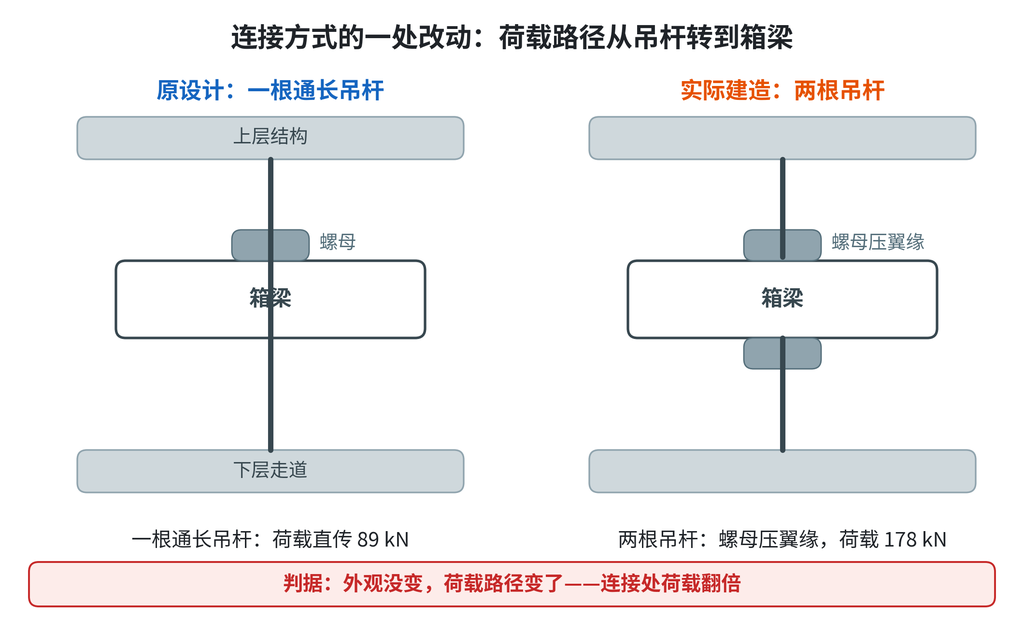

- 原设计（左）：一根通长吊杆穿过 4 楼箱梁，2 楼荷载不经过箱梁
- 变更（右）：两层各一根，2 楼荷载改“穿过”箱梁，4 楼连接托住两层
- 提出者是 Havens：它既是吊杆制造商，也是施工方
- 动机：免去长吊杆穿过两层的麻烦，省工省时
- 改动图只盖 G.C.E. 的章：没有计算书，也没有变更单
- 一句话：改的是吊杆根数，动的是传力路径

## 荷载计算：89 kN 变成 178 kN

- 原设计每个 4 楼连接承担：4 楼走道自重与人群活载约 89 kN
- 2 楼走道的 89 kN 由通长吊杆直接传至屋盖，连接处“看不见”这份荷载
- 变更后，下杆的 89 kN 经下翼缘、腹板、上翼缘传到上杆，连接承担 178 kN
- 连接承载力未变：箱梁焊缝与螺母承压面仍按原设计，约 133 kN

$$N_1 = 89 + 89 = 178\ \mathrm{kN}$$

$$K_0=\frac{133}{89}=1.49,\qquad K_1=\frac{133}{178}=0.75$$

- 0.75 的含义：不是余量小，而是在设计荷载下已经超载约 33%
- 若要恢复 1.5 的安全系数，连接承载力需提高到约 267 kN
- 一句话：荷载翻倍、承载力不动，安全系数被直接砍半

## 设计复核的缺失：谁复核、复核了什么

- 设计方 G.C.E.：Duncan 任项目工程师，负责设计图准备与深化图复核；Gillum 为总工、注册工程师
- 复核通常覆盖：尺寸、标高、材料表、碰撞检查，以及“是否符合原设计意图”
- 没有复核的：连接处的实际受力；吊杆由一根改两根后，箱梁要不要加强
- 变更藏在 Havens 的深化图里：无计算书、无变更单、无重新签发的设计图
- 复核痕迹：只有 G.C.E. 的印章；没有计算，没有第二人独立验算
- 制度缺口：业主未请独立第三方审查天桥设计；1979 年后也只审查屋顶
- 结果：自校、审核、签章三道都“过”了，但没人问“荷载变了吗”
- 一句话：复核不是把图看一遍，是把传力路径重走一遍

## 施工方的责任与沟通：电话与图纸

- Havens Steel：吊杆制造商兼施工方，按深化图下料、加工、安装
- 变更动机：一根长吊杆要穿过两层走道，穿装、对中、张拉都费工
- 沟通方式：电话；Havens 称已获 G.C.E. 同意，G.C.E. 称从未接到
- 图纸流：Havens 深化图 → G.C.E. 盖章 → 返回工厂 → 加工 → 现场安装
- 缺失的书面环节：RFI、变更单、计算书、回执、复核记录，都没有留下
- 法庭同时认定 Havens 未尽责审核图纸、未特别标注连接变化
- 但责任仍归 G.C.E.：它有最终检查权，也有向施工方清楚传达设计意图的义务
- 一句话：口头同意在法庭上不是证据，在工程上更不是授权

## 材料与工艺：箱梁、吊杆与焊缝

- 箱梁：两根 C 型钢对焊成箱形，沿梁长有两道纵向焊缝
- 吊杆：φ32 mm 钢棒，端部车螺纹；上端螺母压在上翼缘，下端螺母吊住 2 楼
- 传力：2 楼荷载 → 下螺母与垫板 → 下翼缘 → 腹板与焊缝 → 上翼缘 → 上螺母
- 失效：箱梁沿纵向焊缝开裂，下翼缘被拉开，螺母与垫板被拉穿
- 螺栓：走道与工字钢用螺栓连接；吊杆节点不用螺栓，用双螺母
- 两类紧固件的失效模式不同：螺栓看预紧与剪切，螺母看承压与螺纹
- 工艺不是主因：材料、焊缝、螺纹按原设计做；变的是它们要传的力
- 一句话：连接件不会突然变弱，只会被要求变强

## 事故当晚：茶舞会与连续倒塌

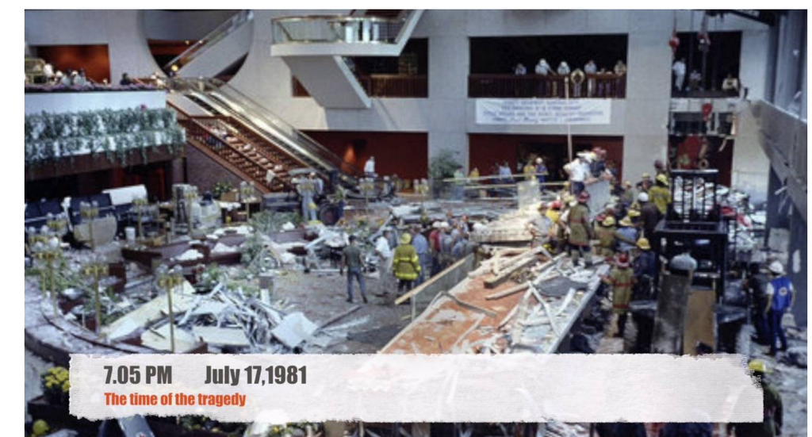

- 1981 年 7 月 17 日星期五晚，中庭茶舞会，约 1600 人在场
- 19:05，4 楼连接失效，两层走道与人群一起坠入中庭
- 回廊与一层大厅同样站满人，救援持续数日
- 链条：连接失效 → 4 楼坠落 → 砸中 2 楼 → 两层落地
- 无备用传力路径，“全有或全无”：114 人死亡、216 人受伤
- 一句话：失效只用一秒，代价用了四十年才结算

## 1979 年屋顶坍塌：被放过的前兆

- 1979 年 10 月 14 日，仍在施工的中庭屋顶坍塌，面积超过 250 m²
- 业主皇冠中心另聘独立结构公司 Seiden Page 调查，结论指向屋顶荷载
- 由 Gillum 更正屋顶设计；但委托范围仅限屋顶，不含天桥
- G.C.E. 曾三次要求在现场设设计代表，均因成本控制被业主拒绝
- 三次拒绝省下的钱，与 114 条生命、1.4 亿美元相比可以忽略
- 若那次调查覆盖全楼，天桥连接变更很可能被发现，两年后的坍塌或许可以避免
- 一句话：前兆不是信息不足，是范围被合同切小了

## 调查与法庭：两个关键事实

- 调查：结构失效分析、图纸比对、材料与焊缝试验、目击证词；庭审持续 26 周
- 事实一：Havens 称电话通知并获同意；G.C.E. 否认接到，改后图纸却盖着 G.C.E. 的章
- 事实二：1979 年屋顶坍塌后，G.C.E. 未做应有调查；三次现场代表请求被拒
- 技术结论：天桥连接不满足建筑规范；设计图存在错误、误差与疏忽
- 判决：严重疏忽（gross negligence）、行为不当、不专业行为
- 责任逻辑：谁有最终检查权，谁承担最终责任；“谁提出”不等于“谁负责”
- 一句话：法庭审的不是电话有没有打，而是你有没有把住最后一道关

## 纪律裁决与执照处理（1985 年 11 月）

- 1985 年 11 月，密苏里行政听证委员会法官 James B. Deutsch 作出裁决
- Duncan（项目工程师）：对职业职责“明知故犯的漠视”（conscious indifference）
- Gillum（总工、注册工程师）：未密切监督项目工程师，同样被定性
- 处罚：两人被吊销密苏里州执业执照；G.C.E. 被撤销工程公司资质
- 民事：赔偿与和解累计约 1.4 亿美元；事故到裁决历时四年多
- 意义：执照不是终身荣誉，是附条件的公共信任；签章就是法律上的签字
- 一句话：最重的处罚不是罚款，是剥夺继续做工程师的资格

## 责任判定：为什么设计方承担全部责任

- **判据**：结构工程师对设计项目负全部责任——这一条在事故后由 ASCE 通过政策明确
- 理由一：**最终检查义务在 G.C.E.**——印章在手，责任在手
- 理由二：**设计意图的沟通责任在 G.C.E.**——法庭认为工程师应主动、清楚地传达关键节点的设计要求
- 理由三：**对已知前兆未尽调查**——1979 年屋顶坍塌后未追查全楼
- 理由四：**错误地过度信任分包商**——对 Havens 的图纸审核过度依赖
- 结论：“谁提出变更”不等于“谁负责”；责任跟着**签章与最终把关**走

## 凯悦案的判据：事实—裁决—制度

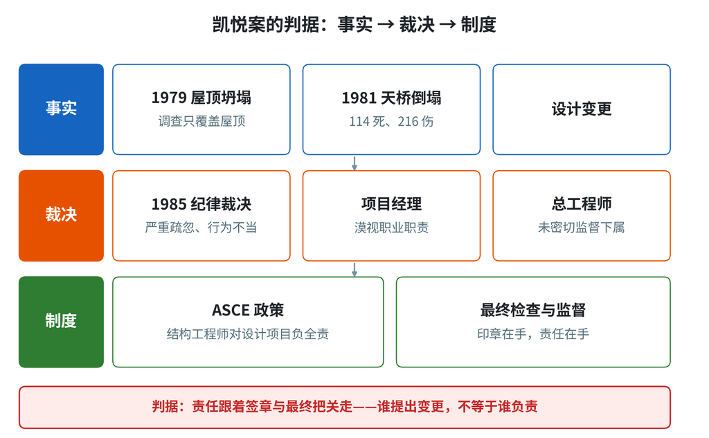

- **是什么**：一根吊杆改两根，连接荷载从 89 kN 抬到 178 kN
- **为什么**：变更未复核就盖章，1979 年屋顶坍塌的警报又只查了屋顶
- 结果：1981-07-17 两层走道坠落，**114 人死亡、216 人受伤**
- **怎么判责**：看三件事——谁签章、谁负最终检查、谁该发现前兆
- 裁决与制度：项目经理漠视职责、总工未监督；ASCE 定全责
- 一句话：责任跟着**签章与最终把关**走，不跟“谁提出变更”走

## ASCE 政策与结构工程师责任制度

- 1983 年，ASCE 成立委员会调查凯悦事故
- 1985 年裁决前，ASCE 宣布政策：结构工程师对其设计的结构安全负责
- 背景：设计方、施工方、分包方的责任边界模糊，事故后必须写清
- SER（Structural Engineer of Record）：签章的结构设计负责人，对整体结构设计负责
- 职责通常包括：设计依据、计算书、图纸签章、变更复核、施工符合性、竣工记录
- ASCE 还敦促土木工程师“仅在能预见整个制造与建造过程时”接受设计委托
- 迁移到智能制造：SER 类似系统安全或技术签核责任人（sign-off authority）
- 一句话：制度把“谁负责”从事后争论变成事前约定

## 从案例看“责任链”的五道防线

凯悦的失效不是一处，而是五道防线同时失守。

| 防线 | 应有动作 | 本案实况 | 后果 |
| --- | --- | --- | --- |
| 设计计算 | 按最不利组合验算连接 | 只按单层走道荷载设计 | 连接余量本就偏小 |
| 深化与变更 | 变更单、重算、批准 | 电话改双吊杆，无计算书 | 荷载翻倍未被发现 |
| 复核签章 | 独立复核传力路径 | 只核对图面，盖章放行 | 最后一道技术关失守 |
| 现场代表 | 驻场核对图纸与实物 | 三次请求被业主拒绝 | 变更落地无人见证 |
| 业主与监管 | 独立审查，覆盖全结构 | 1979 年只查屋顶 | 前兆被范围切掉 |

- 五道防线中任何一道有效，事故都不会发生；但它们同时“合理”地失效了
- 技术层看“算得对不对”，组织层看“谁复核”，制度层看“有没有独立审查”
- 现场代表不是“监工”，是把设计意图翻译成施工动作的人
- 五道防线不是五个部门，而是五次停下来问一句的机会
- 判据：每一道防线都要能回答“谁做、做什么、留下什么记录”
- 一句话：安全不是某一道防线的强度，而是整条链的连通性

## 责任的四种类型

| 类型 | 含义 | 凯悦案 | 737 MAX |
| --- | --- | --- | --- |
| **因果责任** | 我的行为客观上导致了这个结果 | 改图与盖章的行为链 | MCAS 逻辑与单传感器设计 |
| **角色/职业责任** | 由职业角色带来的应尽义务 | 结构工程师的最终检查义务 | 适航认证与安全评估义务 |
| **法律责任** | 违反法律、法规、规范后的追责 | 严重疏忽 → 吊销执照 + 赔偿 | 与司法部 25 亿美元和解 |
| **道德责任** | 即使合法，仍应承担的良心与声誉责任 | 过度信任分包商、未查前兆 | 内部嘲讽安全文化、隐瞒缺陷 |

- 四种责任**不同步**：合法不等于没有道德责任；因果责任可能落在执行者，角色责任落在签章者
- 事故调查的本质：把四张网叠起来，看哪一层破了、破在谁身上

## 照顾标准：过失的界线在哪里

- **照顾标准**（standard of care）：同行中正常胜任、声誉良好的执业者，在同样情形下通常提供的服务水平
- 关键区分：社会买下工程师的**正常误差**；只有**超过一定水平的错误**才构成过失
- 过失的四个要件（法律与道德同构）：① 有遵守标准的义务 ② 未达到标准 ③ 与损害有相当因果 ④ 造成实际损害
- 凯悦案：变更未复核、现场无设计代表 → **明显低于可接受实践**，构成过失
- Citicorp 案：满足纽约市 90° 风荷载规范，仍不足以证明安全 → **合规不等于无过失**
- 两案对照：一个“低于标准”，一个“标准本身不够”
- 一句话：**照顾标准是底线，不是免罪符**

## 监督责任与组织原因

- **负责监督**（responsible charge）：在盖章批准前，必须行使审慎的监督——即“合理注意”
- 监督不是逐一看每一张图，而是**建立能让问题浮出来的机制**
- 凯悦案：若有负责的监督，变更会进入视野；几行简单计算就能发现结构不安全
- Columbia 事故调查：把事故原因分为**物理原因**与**组织原因**，二者同等重要
- 组织能否承担道德责任？三个特征支持“能”：**决策机制、政策与文化、独立于个人的组织利益**
- 组织至少可被三种方式追责：**批评、赔偿、改革**
- 一句话：**组织文化不是背景，它本身就是事故原因**

## 事故之后的制度变化

- **变更控制**：设计变更必须回到计算与复核，口头同意不构成技术依据
- **现场设计代表**：施工配合制度化，设计方对“图纸与实物一致性”有现场责任
- **独立审查范围**：审查必须覆盖全结构，不能只查出问题的部位
- **签字盖章责任**：ASCE 明确结构工程师对设计项目负全部责任
- 对智能制造的四条对应：工程变更单（ECN）、设计评审、FMEA 的探测度、MES 的变更追溯
- 一句话：**制度是把个人的一次侥幸，变成组织的一次必查**

## 案例的工程伦理教训（五点）

- 教训一，可预见即责任：G.C.E. 有能力算却没算，不能推给“没收到通知”
- 教训二，诚实面对错误：把变更推给“沟通失误”，比错误本身更伤职业信任
- 教训三，预防优于补救：1979 年的屋顶坍塌是免费警报，被委托范围关掉
- 教训四，专业判断不可外包：把复核交给分包商，等于把责任也交出去
- 教训五，组织必须为安全留资源：三次拒绝现场代表，是最贵的省钱
- 共同点：没有人故意作恶，每个环节都做了“局部最优”
- 一句话：伦理不是额外的美德，是职业判断在压力下仍不缩水

## 类案比较：Citicorp 与 Kardon 标准

- 1977 年纽约，59 层花旗银行大厦；底部四根柱位于边中点，靠斜撑转换
- 施工把原设计的焊接节点改成螺栓；LeMessurier 得知后重新计算
- 规范只要求 90° 风向；他另算 45° 斜风，发现节点应力不足
- 结论：约 16 年一遇的风暴即可导致节点破坏与连续倒塌
- Kardon 标准：同行中正常胜任、信誉良好的工程师，在同期、同地、同条件下通常提供的服务水平
- 规范是下限，注意义务是同行标准；满足规范，不能证明已尽注意义务
- 行动：报告业主、夜间焊接加固、准备疏散预案，事后公开真相
- 一句话：合规是底线，不是天花板

## 类案比较：737 MAX 与组织失效

- 狮航 JT610 与埃航 ET302 两起事故共 346 人遇难
- 直接原因：MCAS 靠单一迎角传感器反复压低机头
- 变更：权限由 0.6° 扩到 2.5°，未做完整失效影响评估
- 组织失效：进度压力、监管委托（ODA）、评估碎片化、异议消音
- 同构：变更未回计算、单点失效；差别只在失守层级（项目层／组织层）
- 一句话：责任被切成碎片，就没人对整体负责

## 案例讨论题（三问）

- 问题一，变更：Havens 电话要求把单吊杆改双吊杆，你作为 G.C.E. 项目工程师怎么答复？需要哪些书面材料才签字？
- 问题二，前兆：1979 年屋顶坍塌后，业主只委托查屋顶；你作为结构负责人，走哪三条行动线？
- 问题三，迁移：今天供应商在 ECN 中改了载荷路径，你签不签？设计什么流程让“凯悦式错误”不可能发生？
- 提示一：把“同意或不同意”翻译成可核查的条件——计算书、变更单、复核人、回执
- 提示二：区分合同范围与职业责任范围；合同可以限定服务，不能限定良知
- 提示三：用五道防线逐条对照，找出你所在组织最薄的一环
- 一句话：好的讨论不落到“谁坏”，而落到“哪一步可以不同”

## 本部分小结

- 事实链：1979 年屋顶前兆 → 1981 年天桥坍塌 → 1985 年纪律裁决与 1.4 亿美元赔偿
- 力学链：单吊杆改双吊杆 → 连接荷载 89→178 kN → 安全系数 1.49→0.75
- 责任链：Havens 提出 → G.C.E. 盖章 → 设计方承担最终责任
- 制度链：ASCE 政策、SER 制度、变更控制、独立复核、现场设计代表
- 伦理链：可预见性、诚实、预防、专业判断不被外包
- 方法链：先还原传力路径，再还原决策路径，最后还原责任路径
- 一句话：凯悦案不是“坏人做坏事”，是“每个环节都做了局部最优”
- 过渡：下一部分从个案转向职业伦理准则——工程师共同体的自我约束

## 推导留给 AI：凯悦案例（汇总）

- 分别用“可预见性 × 可控制性”和“签章即责任”两条判据，判定 Havens 与业主的责任比例，并说明两种判据为何结论不同。
- 如果 1979 年屋顶坍塌后的调查覆盖全楼，事故链会在哪一步被切断？用最小割集的语言说明。
- 把凯悦案的变更流程改写成一份现代 ECN 流程，列出必须留下哪 6 份记录。
- 本案中“电话通知”是否存在始终无法证实。请设计一条制度，使这类事实不再依赖证词。

# 第三部分 · 工程师职业伦理准则

- 职业是什么：Davis 定义、七项判据与自查表
- 伦理的三层次：禁止性、预防性、志向性
- NSPE 伦理准则：总则、六条基本准则、执业规则
- 中国机械工程师职业道德规范、台湾工程师信条
- 切尔诺贝利：设计缺陷、操作失误与刻意隐瞒

## 职业伦理为什么必要：三重不对称

- 信息不对称：委托人看不懂图纸、算不了荷载，无法判断建议的质量
- 后果不对称：判断错误的代价由公众承担，判断者只承担一部分
- 监督不对称：专业工作无法被持续监视，只能靠执业者自律
- 三者叠加，委托关系只能建立在信任上：信任替代了监督
- 专业自治：行业以自律换取执照与市场准入，伦理是自治的代价
- 失效有三种：不会做（能力）、不想做好（利益）、不知对谁负责（忠诚）
- 行为规范的层次：**礼节 → 法律 → 道德 → 职业道德**；职业道德不是额外要求，而是大众道德在专业场景中的延伸
- 准则的功能：把模糊的信任变成可核查的承诺与可追责的动作
- 一句话：伦理不是道德加分，而是知识不对称下的替代性控制

## 工程伦理的三种规范来源

- 法律：国家强制的最低线，违反有明确罚则；但立法滞后，标准可能不足
- 职业准则：行业自治的角色义务，比法律细、比道德具体
- 道德：诚实、不伤害、尊重人等普遍原则，是评价法律与准则的最终依据
- 分工：法律管“不许”，准则管“应当”，道德管“为什么应当”
- 准则可以高于法律：法律允许的，准则未必允许
- 法律与道德冲突时，良知优先：执行命令不能免除道德责任
- 三者常重叠：公众安全优先同时是法律义务、准则义务与道德义务
- 一句话：合规是最低要求，不是伦理的终点

## 职业是什么：Davis 定义与七项判据

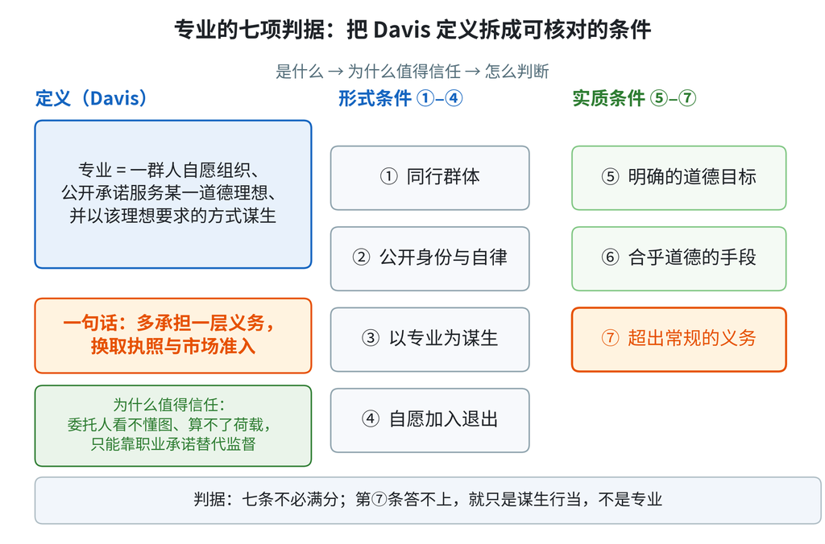

- **是什么**：专业＝自愿组织、公开承诺道德理想、并以此谋生的一群人
- **为什么**：委托人看不懂图、算不了荷载，只能靠职业承诺替代监督
- 七条：①多人②公开③谋生④自愿⑤道德目标⑥道德手段⑦**超常规义务**
- 判读：①②③④判“像不像”，⑤⑥判“对不对”，⑦判“值不值得信任”
- **怎么判断**：只按合同办事是承包方，自愿多做一步才是专业
- 一句话：职业用“多承担一层义务”换取执照与市场准入

## 判据：一个群体是不是专业（自查七条）

| 特征 | 判据问句 | 不算专业的信号 |
| --- | --- | --- |
| ① 多人组成 | 有没有稳定的同行群体？ | 一个人自称“专家” |
| ② 公开身份 | 是否对外声明标准、接受评议？ | 只对内承诺 |
| ③ 以专业谋生 | 这是主业还是兼职？ | 业余爱好 |
| ④ 自愿进出 | 入会退会是否自愿？ | 强制指派 |
| ⑤ 道德目标 | 服务的理想是什么？ | 只服务股东 |
| ⑥ 道德手段 | 有没有禁用手段清单？ | 靠回扣拿单 |
| ⑦ 超常规义务 | 法律没要求的，做不做？ | 只求不违法 |

- 用法：七条不必条条满分，但第⑦条答不上，就只是“谋生行当”
- 判据：**能不能公开说“我们对公众有额外义务”**

## 伦理的三层次：底线、防线、天花板

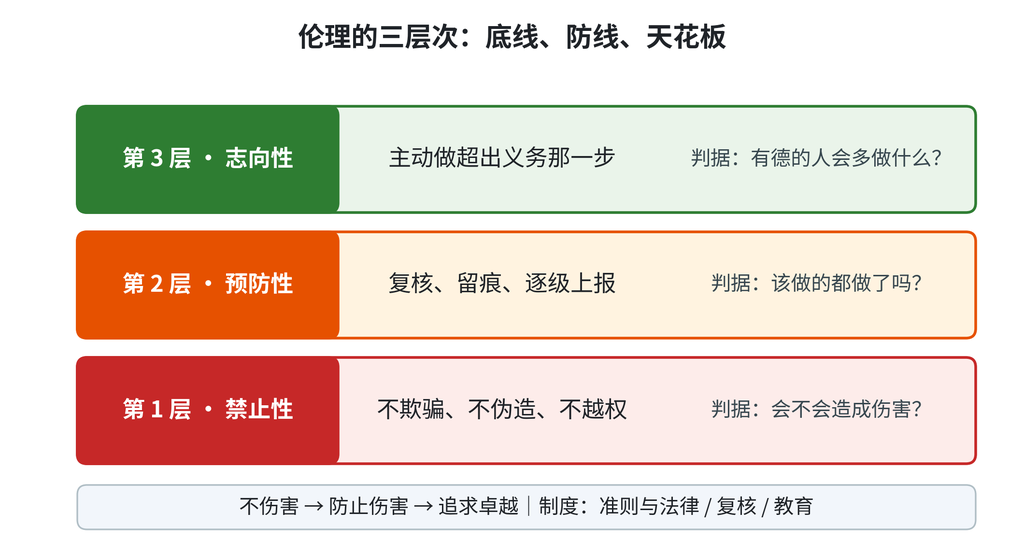

- **是什么**：禁止性（不做错事）→ 预防性（排除伤害）→ 志向性（追求卓越）
- **为什么**：只讲“不违法”＝把职业降格为合规，事故多在“本可预防”层
- **怎么判断**：会造成伤害吗？该复核留痕的做了吗？有德的人会多走哪一步？
- 制度对应：禁止靠准则与法律，预防靠复核与流程，志向靠教育与共同体
- 凯悦：变更未复核、1979 年前兆未追查，两处都是预防性失守
- 一句话：**底线靠守，防线靠建，天花板靠养**

## NSPE 准则：总则与三层规则

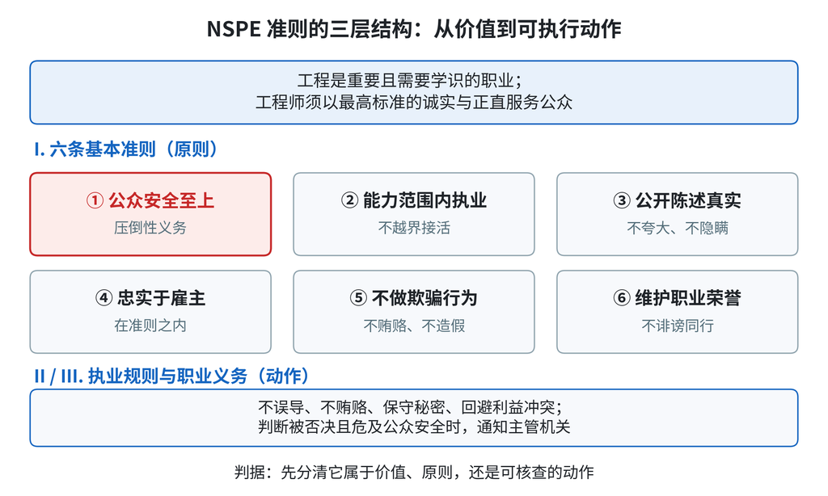

- 全称：美国国家职业工程师协会（NSPE）伦理准则
- 总则：工程是重要且需学识的职业，工程师须**诚实、公正、公平、衡平**
- **Ⅰ 基本准则**：6 条只给原则，第一条把公众安全置于最高位
- **Ⅱ 执业规则**：通知、批准、保密、报告；**Ⅲ 职业义务** 9 条
- 三层关系：总则给价值，准则给排序，规则给动作——第三层才可举证

## 六大基本准则（一）

1. **把公众的安全、健康和福祉放在首位**（hold paramount the safety, health, and welfare of the public）
2. **只在自身胜任的领域提供服务**
3. **只发表客观、真实的公开声明**
- 第一条是压倒性义务：当它与雇主利益冲突时，**优先于雇主**
- 第二条是动态的：胜任 = 教育 + 经验 + 具体技术领域，三者缺一不可
- 第三条约束的是“对外说话”：报告、证词、公开评论都必须有事实依据

## 六大基本准则（二）

4. **作为雇主或客户的忠实代理人或受托人行事**
5. **避免欺骗性行为**
6. **以荣誉、负责、合乎伦理与合法的方式行事，提升职业的荣誉、声誉与价值**
- 第 4 条与第 1 条张力最大：忠实于雇主，但不能以公众安全为代价
- 能力边界：不签无能力的事项，也不签非自己准备或控制下的文件；可总协调项目，但每段须由合格者签章
- 第 5 条包括不伪造资历、不夸大责任、不虚假宣传
- 第 6 条把“个人行为”与“职业声誉”绑定：职业声誉是**公共资产**，不是私人物品

## 执业规则：四条关键条款

- **II.1.a**：工程师的判断在危及生命或财产的情况下被否决时，应通知雇主或客户，**并通知相应主管机关**
- **II.1.b**：只批准**符合适用标准**的工程文件（不签字、不盖章于不合规图纸）
- **II.3.a**：报告、声明、证词必须客观真实，包含所有相关信息，并注明**日期**
- **II.1.f**：知悉违反本准则的行为，应向职业团体报告；必要时向公共机关报告，并配合提供材料

**配套条款**：II.4.a 披露已知或潜在利益冲突；III.4 未经同意不得披露客户或雇主的商业与技术秘密。

> 一句话：准则把“什么时候必须说、向谁说、留下什么”写成了**可执行动作**。

## ASCE 准则：七条基本准则

- 全称：美国土木工程师学会（ASCE）伦理准则
- 沿革：1914 年首次制定，2020 年 10 月最新修订
- ① 公众安全、健康与福祉优先，并努力遵循可持续发展原则
- ② 只在胜任的领域提供服务
- ③ 公开陈述客观、真实
- ④ 作为雇主或客户的忠实代理人，避免利益冲突
- ⑤ 以服务业绩建立声誉，不进行不公平竞争
- ⑥ 维护职业荣誉、正直与尊严，对贿赂、欺诈、腐败零容忍
- ⑦ 终身职业发展，并为下属提供发展机会
- 与 NSPE 的差别：可持续写入第一条，培养后进写成义务

## 中国机械工程学会：职业道德规范

- 文件：《机械工程师职业道德规范（试行）》，2003 年 11 月
- 定位：与《公民道德建设实施纲要》衔接，国家法规放在第一条
- ① 以法律法规和学会制度规范行为，不损害公众环境、福利与健康
- ② 在能力与专业范围内服务并明示资格，只签亲自准备或直接监控下的文件
- ③ 靠职业表现维护职业尊严，公开报告诚实公正，反对金钱至上
- ④ 职业关系中不因种族、宗教、性别、年龄、国籍、残疾而歧视
- ⑤ 做忠实代理人，保守商业与技术机密，提示潜在利益冲突
- ⑥ 诚信对待同事，传授技术知识，客观评价他人工作
- 一句话：六条与 NSPE 六条大体对应，差别在“法规优先”的写法

## 台湾工程师信条：八条四字口诀

| 对象 | 信条（各四字） | 释义要点 |
| --- | --- | --- |
| 社会 | **守法奉献 · 尊重自然** | 恪遵法令规章，保障公共安全，增进民众福祉；维护生态平衡，珍惜天然资源，保存文化资产 |
| 专业 | **敬业守分 · 创新精进** | 发挥专业知能，严守职业本分，做好工程实务；吸收科技新知，致力求精求进，提升产品品质 |
| 雇主 | **真诚服务 · 互信互利** | 竭尽才能智慧，提供最佳服务，达成工作目标；建立相互信任，营造双赢共识，创造工程佳绩 |
| 同僚 | **分工合作 · 承先启后** | 贯彻专长分工，注重协调合作，增进作业效率；矢志自励互勉，传承技术经验，培养后进人才 |

- 结构：**四类对象 × 两条信条 = 八条**，每条四字，便于记忆与宣讲
- 细则举例：须签署的图说应确实办理或督导审核；不做虚假之事，不图不当利益
- 注意顺序：**社会在前，雇主在后**——这是价值排序，不是排版顺序
- 判据：把每条口诀翻译成“谁、在什么场景、做什么动作”，才算会用

## 三套准则对照

| 维度 | NSPE 准则 | 中国机械工程师规范 | 台湾工程师信条 |
| --- | --- | --- | --- |
| 结构 | 总则 + 6 条基本准则 + 执业规则 | 6 条 | 4 类 8 条 |
| 首要义务 | 公众安全、健康、福祉优先 | 不损害公众利益 | 守法奉献、保障公共安全 |
| 胜任要求 | 只在胜任领域执业 | 明示资格、不接不能胜任的活 | 敬业守分 |
| 雇主关系 | 忠实代理人或受托人 | 忠实代理人、保守机密 | 真诚服务、互信互利 |
| 同行关系 | 不恶意损害他人声誉 | 诚信对待同事 | 分工合作、承先启后 |
| 特色 | 有可执行的执业规则 | 与法律法规直接衔接 | 四类对象、八条口诀 |

## 准则的效力：公众承诺而非私约

- 事实：只有少数执业工程师是学会会员，准则却声称约束所有工程师
- 理由一：条款源于普通道德，准则只是把既有义务写清楚
- 理由二：义务来自角色而非会籍，只要执业就承担同样义务
- 理由三：执照由公众授予，执业权附带公众安全义务
- 历史：1970 年代以前，多数准则把忠于雇主列为首要责任
- 转变：公众安全写入第一条，是行业自己改写的结果
- 执行：法院更看重执照委员会与监管机构的规则，学会准则次之
- 真正效力：可被引用——纪律听证、事故调查、专家证词

## 工程共同体的自我治理

- 为什么需要自我治理：知识不对称使外部难以监督，**行业必须自己建立标准与惩戒机制**——执照由共同体授予，也由共同体收回
- 五个机制：
  1. **职业协会**：制定与修订伦理准则（NSPE、中国机械工程学会、中国工程师学会）
  2. **执照与认证**：执业资格考试、注册工程师、单位资质等级；**吊销执照**是最重处罚
  3. **伦理准则**：六条基本准则 + 可执行的执业规则，使惩戒有依据
  4. **同行评审**：设计评审、事故调查、论文与方案评审——技术判断必须由同行检验
  5. **继续教育**：知识更新以保持“胜任”，准则要求持续职业发展
- 失效的后果：切尔诺贝利（设计者隐瞒）、737 MAX（监管外包）→ 自我治理失效时，外部监管必须介入

## 准则与雇主义务：忠诚的边界

- 冲突结构：雇主买的是服务与忠诚，公众要的是安全，工程师同时欠两者
- 管理者的逻辑：团队精神、责任模糊、细节下推、功劳上推、不留文字
- 工程师的逻辑：安全与质量优先，判断必须可核查、可追溯
- 准则的排序：第一条压倒第四条，忠实代理不能以公众安全为代价
- 合法出口：先内部反映，再逐级上报，最后才走出组织
- 批判性忠诚：忠诚不是服从，是把坏消息及时、有方案地送到决策者面前
- 不能做的事：签不该签的图、改数据、把风险写成“可接受”而不留依据

## 利益冲突：四种类型与处理

- 定义：在职业角色中，某些利益使判断不太可能服务于委托人有权期待的利益
- 有冲突不等于不道德；怎么处理才决定是否不道德

| 类型 | 情形 | 例子 | 处理 |
| --- | --- | --- | --- |
| 实际 | 当下已存在 | 持股供应商参与选型 | 披露并回避 |
| 潜在 | 接活后才发生 | 投标后评审同批标书 | 事先披露或退出 |
| 表面 | 旁人合理怀疑 | 亲属公司中标 | 披露并复核 |
| 承诺 | 时间精力冲突 | 同期接三个项目 | 排期或拒绝 |

- 第四种严格说不是利益冲突，而是承诺冲突
- 依据：NSPE 披露已知或潜在冲突；中国规范第五条提示冲突

## 保密义务与公众安全的边界

- 保密范围：客户提供的信息，以及为其工作过程中获得的信息
- 前雇主的图纸、工艺与数据同样受保护，离职不等于解禁
- 两种失手：不该说时说了；该说时不说
- 判据一：是否存在对生命安全的紧迫威胁——有，公众安全优先
- 判据二：法律或准则是否要求披露——是，保密义务自动让位
- 程序：先告知客户并劝其整改，无效再向主管机关报告
- 创造性中间道路：先争取整改，把披露作为最后手段
- 一句话：保密是默认值，不是挡箭牌

## 吹哨（whistleblowing）：定义与三个条件

- 定义：内部人绕开组织既定渠道，把组织不希望公开的信息告知公众或权威
- 两个特征：内部人身份；绕开既定渠道
- 四种形态：内部或外部、实名或匿名
- 为何需要证成：吹哨违反对组织的忠诚，伤害组织与同事
- 条件一：将对公众造成的伤害严重且可观
- 条件二：已向管理层报告而未获解决
- 条件三：已穷尽组织内部渠道
- 三条同时满足，吹哨在道德上可允许，但未必必须

## 吹哨的两种证成：防害与共谋

**DeGeorge：防害论**

- 正当性：阻止可预见的严重伤害
- 义务另需：能说服公正旁观者的证据、公开确能阻止伤害
- 批评：门槛过高、上级可能就是问题源、来不及走完渠道

**Davis：共谋论**

- 正当性：不成为错误行为的参与者
- 六条件：信息源于本职工作、自愿加入、组织犯严重错误
- 自己的工作会助成该错误、信念有据、信念为真
- 差别：一个问“能否防害”，一个问“我是否参与”
- 实践：两条理由常同时成立，写材料时两条都讲

## 吹哨的程序与后果

- 程序一：先用组织内正式或非正式渠道——伦理热线、监察员、异议程序
- 程序二：决定保密还是联合同事，一个人容易被说成闹情绪
- 程序三：对事不对人；书面记录时间、对象、内容与答复
- 程序四：带着解决方案提问题，而不是只提交一份控诉
- 后果：Boisjoly 举报后被边缘化，付出了职业代价
- 后果：Lorenz 因拒绝作假被解雇，17 年后州最高法院才认可其诉由
- 保护：1981 年密歇根州首立吹哨人法，1989 年联邦《吹哨人保护法》
- 激励：2002 年 SOX 与 2010 年 Dodd-Frank，举报可获罚款的 10%～30%

## 拒绝参与：不服从的三种形态

- 组织不服从：对组织政策或行动的抗议或拒绝
- 形态一：相反行动，工作之外做与公司利益相悖的事
- 形态二：不参与，以道德或职业理由请求退出某项任务
- 形态三：抗议，公开反对某项政策或行动，吹哨属此类
- 职业理由与个人理由：拒做不安全产品可援引准则，拒做军工只能援引个人道德
- 边界：不能把良心当借口，逃避无聊或难相处的任务
- 雇主义务：能安排时应尊重基于良心的退出请求
- 一句话：拒绝参与是权利，但要讲依据、提替代、留记录

## 切尔诺贝利：事故链

[figure not shown]

- 1986 年 4 月 25 日夜，4 号机组 **176 名员工**奉命做“省电”试验
- **设计缺陷**：РБМК-1000 反应堆低功率时不稳定；控制棒尾端为石墨，插入初期反而使功率上升；设计者知悉危险却**蓄意隐瞒**
- **操作失误**：降功率过快；拔出超过规程数量的控制棒
- 1:23:40 按下“紧急停堆”→ **7 秒后**堆芯爆炸
- 屋顶防火涂层应为防火材料，实际用了**易燃沥青** → 火势迅速蔓延
- 后果：8 吨多强辐射物质泄漏；普里皮亚季城废弃

## 切尔诺贝利的责任分析

- **设计方**：知道缺陷而隐瞒 → 违反“客观真实”与“公众安全优先”
- **管理层**：厂长只有燃煤电厂经验，总工程师来自常规能源厂 → 违反“只在胜任领域执业”
- **操作层**：降功率过快、超量拔出控制棒 → 违章操作
- **监管层**：核安全审评缺位、应急准备不足 → 制度失守
- 伦理结论：**技术缺陷 + 组织缺陷 + 道德缺陷（隐瞒）** 三者叠加
- 隐瞒是最重的伦理罪错：它剥夺了所有人**知情同意的机会**
- 与 FMEA 的对应：把已知失效模式写下来并跟踪到底，就是对抗隐瞒的制度手段

## 胜任力：能力边界与持续学习

- 胜任三要素：教育、经验、具体技术领域，缺一不可
- 四个自问：做过同类项目吗、懂这套标准吗、有人复核吗、出错谁承担
- 签字分界：只签自己准备或在自己指导与控制下准备的文件
- 总协调可以签全项目，但每个技术段须由合格者签章
- 持续学习的制度形式：继续教育学时、注册复证、内部技术评审
- 学习三种来源：项目复盘、同行评审、带教与传承
- 不胜任的三种信号：总说“以前都这么干”、拒绝复核、把标准当上限
- 一句话：执照证明你曾经合格，学习证明你现在仍合格

## 案例分析：准则应用练习

- 情境：公司让你选发动机轴承及供应商；父亲经营轴承公司，你是法定继承人
- 前提：父亲公司的产品确实合格，价格与服务也不差
- 三个选项：选父亲公司、因冲突改选别家、上报并回避
- 第一步 识别：表面利益冲突——产品再好，判断的可信度已受损
- 第二步 定位：NSPE 披露已知或潜在冲突；中国规范第五条提示冲突
- 第三步 处理：书面披露，主动回避选型，交第三方按技术标评审
- 第四步 留痕：披露记录、评审记录、回避声明
- 结论：上报并回避最接近，但完整答案还要加“披露 + 留痕”

## 职业伦理复习与练习

- 复习一：默写 Davis 七特征，指出哪一条把职业与行会分开
- 复习二：NSPE 六条与 ASCE 七条各选一条，比较写法差异
- 复习三：写出过失四要件，说明合规不等于达标
- 练习一：写一份五行披露备忘录：对象、事实、影响、处理、请求
- 练习二：用 DeGeorge 三条件与 Davis 六条件判同一吹哨案
- 练习三：为某项目写能力边界声明，列出你不签的部分与理由
- 讨论：准则与上级指令冲突时，按优先级列出五步行动
- 一句话：能把准则写成动作，才算学会

## 推导留给 AI：职业伦理准则（汇总）

- NSPE 六条基本准则中，哪一条最难执行？用一个你熟悉的场景说明它的执行障碍。
- 三套准则都把“公众安全”放在首位，但执行机制不同。请为其中一套设计一个可核查的落地流程。
- 切尔诺贝利事故中，“胜任”这一条在管理层与操作层分别以什么形式被违反？
- 如果准则与上级指令冲突，工程师的合法行动路径有哪些（按优先级排序）？

# 第四部分 · 伦理决策框架与案例

- 工具：事实/概念/应用三分解、划线法、创造性中间道路
- 三种框架：后果论看结果、义务论看义务、美德伦理看品格
- 案例：挑战者号（含偏差正常化）、Citicorp 大楼、波音 737 MAX
- 组织压力下的判断与责任边界

## 伦理判断的第一步：拆成三类问题

- 道德争论常常不是“价值观不同”，而是**事实没对齐**
- 三类问题：
  - **事实问题**：发生了什么、概率多大、数据是否可靠
  - **概念问题**：关键术语怎么定义——“公众安全”“利益冲突”“贿赂”“保密”
  - **应用问题**：这个概念是否适用于这个具体行为
- 处理顺序：先查事实 → 再澄清概念 → 最后判断适用
- 例：“接受供应商的免费论坛邀请算不算贿赂？”先查金额与时点（事实），再定义贿赂（概念），最后判断是否适用（应用）
- 中文方法口诀：**充分调研事实、逐条理清、综合考虑、折衷创新**
- 一句话：**先把问题问对，再谈立场**

## 三种伦理框架总览：后果、义务、品格

| 框架 | 核心提问 | 判据 | 一句话记住 |
| --- | --- | --- | --- |
| 后果论 | 结果好不好？ | 最大多数人的最大幸福 | 算总账 |
| 义务论 | 是否违反义务？ | 准则、权利、可普遍化 | 守底线 |
| 德性论 | 有德的人会怎么做？ | 诚实、勇气、忠诚、卓越 | 看品格 |

- 三个框架回答三个不同问题，**不能互相替代**
- 补充视角：权利论（谁的权利被侵犯）、关怀伦理（关系是否被维系），后面两页展开
- 工程里的常用组合：**后果论排序 → 义务论划界 → 德性论自查**
- 三者给出不同结论时：底线优先，义务论划的那条线不能越过
- 一句话：框架不是答案，是**让答案可被讨论**的语言

## 功利主义：最大幸福原则与计算法

- 边沁、密尔：**效益就是最大的善**，追求最大幸福（maximum happiness）
- 判据：行为适当与否，看它能否给最多的人带来最大的好处
- 译名说明：学界也用“效益主义”，旧译“功利主义”——名字带贬义，内容并不等于自私
- 计算法三步：列出备选 → 把成本与收益折成同一量纲、覆盖全部受影响者 → 取净收益最大者
- 工程形式：风险—收益分析、ALARP（合理可行的最低风险）、安全投入的边际效益
- 期望效用 $E[U]=\sum_{i=1}^{n}p_i u_i$，判据为 $\max E[U]$
- 行为功利算“这一次”，规则功利算“大家都这样”的长期后果
- 算例：加固投入 200 万元，预期减少损失 600 万元，净收益 400 万元
- 一句话：功利主义擅长**排序**，不擅长**守底线**

## 功利主义的优点与局限

- 优点一：可比、可算，能把不同方案排成序
- 优点二：强迫把“隐性代价”写进账本，安全投入不再是口号
- **局限一 定价**：生命如何折成货币？折价系数一改，结论就翻
- **局限二 分配**：总量最大不等于分配公平，常见“收益集中、风险分散”
- **局限三 信息**：概率只是估计，长期后果不可测——风险评估有四大局限
- **局限四 意图**：只看结果，无法解释“好心办坏事”与“违心服从”的差别
- 修正一：把不可侵犯的权利设为**约束条件**，先满足约束再求最大
- 修正二：分配影响单列，并做敏感性分析，看结论是否随折价系数翻转
- 一句话：**能算的地方尽量算，不能算的地方别假装算过**

## 义务论：康德的绝对命令与尊重人

- 康德（1785《道德形而上学的基础》）：只有出于**义务感**的行为，才有道德价值
- 定言令式与假言令式：前者无条件（“不要说谎”），后者有条件（“想省钱就别撒谎”）
- **第一形式（普遍化）**：只按照你同时愿意它成为普遍法则的准则行动
- **第二形式（目的）**：不论对自己或他人，永远把人当作目的，绝不只是手段
- 自挫败检验：如果人人都这样做，这个行为还成立吗——说谎的承诺会让承诺本身失效
- 两种自挫败：行为本身无法普遍化；目的被普遍化摧毁（人人作弊，优势就没了）
- 推论：**知情同意**——只有承担风险者知情并同意，风险才可施加
- 工程含义：有些事结果再好也不能做——欺骗、隐瞒、签不合规的图
- 一句话：义务论给的是**底线**，不是最优解

## 义务论在工程中：不可欺骗与不可剥夺

- **不可欺骗**：不出假报告、不篡改数据、不隐瞒已知缺陷
- 隐瞒的判据：信息是对方合理期待你不会省略的，且省略的意图是误导
- **不可越权**：只批准符合适用标准的文件（准则 II.1.b）；只在胜任领域执业
- **不可剥夺**：知情同意权；拒绝做违心之事的权利（道德权利，不是准则权利）
- 至今没有工程准则写入“良心条款”（right of conscience）
- 义务冲突：Ross 的“初显义务”——守诺、赔偿、感恩、公正、行善、自我改进、不伤害
- 冲突处理：不是取消义务，而是**为破例给出理由**，并把这个理由写下来
- 工程动作：把义务翻译成条款，把条款翻译成流程（复核、留痕、上报）
- 一句话：**准则就是写下来的义务，流程就是执行中的准则**

## 德性伦理：工程师应有的品格

- 亚里士多德：伦理不是规则，而是“**人应该成为什么样的人**”（德性论，亦称美德伦理）
- 六个职业美德：诚实、勇气（敢抗议危害公众的行为）、忠诚、追求卓越、尊重自然、同情与仁爱
- 美德的四个成分：情感（厌恶说谎）、倾向（习惯去做）、认知（相信什么）、认同（我是谁）
- 四个侧面：尊重自主、不伤害、行善、公正
- 评价行为与评价人：行为看规则，人看意图
- 四分类：允许的、不允许的、义务性的、**超义务的**（做了值得赞扬，不做不可指责）
- 工程含义：同样合规的两个设计，美德决定你**多做的那一步**
- 美德需要制度保护：举报者常被孤立，单靠个人品格不可持续
- 一句话：**规则管住下限，品格决定上限**

## 权利论：人权与知情同意

- 权利＝主张＋对应的义务：你有生命权，他人就有不杀害你的义务
- 消极权利（不被干涉）与积极权利（获得支持）；工程伦理多用消极权利
- 格维斯三层级：生命／身体完整／心理健康 → 不被欺骗、知情同意、守诺 → 取得财产与财富
- 层级越高越优先：不能用第三层级的“赚钱”去换第一层级的“生命”
- 侵犯（infringement，削弱）≠ 违反（violation，剥夺）：排污增加患癌概率属于侵犯
- 知情同意三条件：不受胁迫、掌握相关信息、有判断能力
- 三个现实困难：工人没有替代工作；“自愿”存疑；居民难以真正知情
- 工程含义：风险沟通不是公关，是把判断权交还给承担风险的人
- 一句话：**权利是护栏，不是装饰**

## 关怀伦理：关系与照护

- 源头：吉利根（1982）发现道德判断还有“关怀”取向；诺丁斯（1984）把它系统化
- 出发点不同：人不是孤立的自主个体，而是**关系中的存在**
- 核心提问：这个具体的人需要什么？我如何回应？关系是否被维系？
- 四个关键词：关系性、情境性、回应性、具体性
- 与义务论、后果论的区别：不诉诸抽象规则或总量，而看具体关系中的责任
- 工程落点：使用者（人因与无障碍）、维护检修人员（可维护性）、周边社区、一线操作工
- 中国语境：孟子“恻隐之心”与“仁”，与关怀伦理相通
- 局限：容易偏私（只关怀“自己人”）、难制度化、可能滑向家长式作风
- 一句话：**把“公众”还原成一个个具体的人**

## 框架比较：同一案例的不同结论

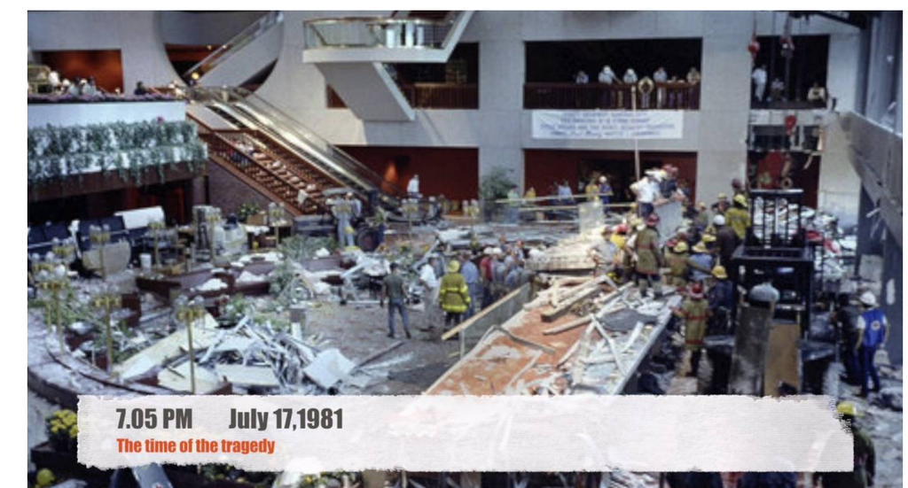

- 同一组事实，五种理由：
- **后果论**：省下的工期 vs 114 条生命的期望
- **义务论**：图纸终检是工程师不可让渡的义务
- **德性论**：过度信任是判断品格的问题
- **权利论**：舞会人群从未被告知风险
- **关怀伦理**：使用者是要保护的具体的人
- 其余四者收敛，后果论最易被输入带偏：**输入被污染，算术就替人作恶**

## 划线法：在两个极端之间定位

| 特征 | 范式贿赂 | 测试案例（Victor） | 范式非贿赂 |
| --- | --- | --- | --- |
| 金额 | 巨大（>1 万美元） | 可观（全程差旅） | 极小（<1 美元） |
| 时点 | 决策之前 | 决策后一天 | 决策之后 |
| 原因 | 个人私利 | 学习＋旅游 | 纯公务 |
| 决策权 | 独揽 | 独揽 | 与他人共担 |
| 产品质量 | 行业最差 | 最好 | 最好 |
| 产品价格 | 市场最高 | 最低 | 最低 |

- 做法：先立两个无争议的端点，再把待判案例逐项定位
- 关键：**圈出权重最大的特征**，而不是数“靠近哪端多”
- 本例：多数特征靠近“非贿赂”，但金额可观，仍应谨慎
- 一句话：划线法给的是**有理由的判断**，不是黑白答案

## 创造性中间道路：冲突的第三条路

- 两难常常是**假两难**：只看到“接受”与“拒绝”两个选项
- 做法：先列出冲突各方的考虑，再问“有没有同时满足更多考虑的方案”
- 四类造法：改变条件（分摊费用）、换人执行（他人代去）、引入第三方（公司政策）、拉长时间（先沟通再定）
- Victor 的中间方案：本人不去、派未参与决策的同事；公司分担费用；公开接受条件；制定收礼政策
- Brad 的串行方案（五个选项，从最优到最差）：再沟通 → 请同事协助 → 先找新工作再向注册机构反映 → 摊牌 → 立即举报
- 排序原则：**能同时满足公众、雇主、自己三方者优先**，越靠后代价越大
- 判据：前两个方案才算真正满意的中间道路，第一个最优
- 中间道路不是妥协，而是**把方案空间扩大**
- 一句话：伦理判断的终点不是“能不能做”，而是“怎么做才对”

## 伦理决策的六步法

| 步骤 | 动作 | 产出 |
| --- | --- | --- |
| 1 定事实 | 数据、概率、时间线、谁在场 | 事实清单与不确定度 |
| 2 清概念 | 关键术语的定义与判据 | 可操作的定义 |
| 3 找相关方 | 谁受益、谁承担风险、谁有权利 | 利害相关方表 |
| 4 跑框架 | 三框架各写一段结论与理由 | 三份理由 |
| 5 造方案 | 中间道路＋串行排序 | 备选方案清单 |
| 6 决策与记录 | 决策、残余风险、复核人 | 决策记录 |

- 与课程设计的三步框架对应：事实与概念 → 相关方与定位 → 决策与辩护
- 与 8D 对应：D2 问题描述≈第 1 步，D4 根因≈第 2 步，D6 验证≈第 6 步
- 不是流水线：任何一步发现新事实，回到第 1 步重走
- 一句话：六步法的产出不是“正确答案”，是**可复核的理由链**

## 案例演练一：赶工期与安全测试

- **情景（教学设定）**：减速器台架试验规范要求 3 台样机各跑 $10^{6}$ 次循环；客户要求提前 6 周交付
- 现状：仅 1 台完成 $6\times10^{5}$ 次循环且无失效；项目经理建议“按现状出报告，写抽检合格”
- **事实问题**：1 台样机跑到 60% 循环无失效，能支持批产放行吗？置信度是多少？
- **概念问题**：“抽检合格”是否等于“满足规范”？“可接受风险”由谁定？
- **规范问题**：对客户的交付承诺与对终端用户的安全义务，哪个优先？
- **三框架**：后果论算期望失效成本；义务论看是否欺骗与越规；德性论问“敢不敢签这个字”
- 行动线：书面说明试验覆盖率 → 给出降额使用条件 → 客户书面确认 → 补做试验
- 一句话：**工期压力不能改变试验结论，只能改变交付方式**

## 案例演练二：虚假检测报告

- **情景（教学设定）**：三件零件孔径超差 0.02 mm，公差为 +0.03／0.00；检验员被要求“把测量值修到公差内”
- 事实：复测 3 次均超差，量具在校准有效期内，可排除测量误差
- **概念问题**：“合格”按实测值判定，还是按“能否装配”判定？返修与让步接收的界线在哪？
- **义务论**：伪造记录即欺骗；只批准符合适用标准的文件（准则 II.1.b）
- **后果论**：放行导致装配干涉与早期失效，返修成本远低于召回成本
- **权利论**：客户与终端用户的知情权；让步接收必须由客户书面同意
- **德性论**：签下这个字的人，还是不是“诚实的工程师”
- 行动线：如实判定 → 开不合格品评审 → 返修或申请让步 → 全过程留痕
- 一句话：**数据的唯一义务是真实，判定的权力属于流程**

## 案例演练三：利益冲突的投标

- **情景（教学设定）**：评标委员会成员，其配偶持有投标方 8% 股份；技术分占 70%
- 定义（戴维斯）：专业角色中的私人利益，使其判断有利于客户的可能性低于客户合理期待
- 要点一：**有利益冲突本身不等于不道德**，如何处理才是伦理问题
- 要点二：区分利益冲突与“承诺冲突”（时间不够、身兼太多）
- 要点三：实际冲突与潜在冲突；公众看到的往往是“表面冲突”
- 准则：披露已知或潜在冲突（NSPE II.4.a）；不得受冲突利益影响（III.5）
- 处理三步：披露 → 回避（不接触标书、不参与评分）→ 剥离（转让股份、退出关系）
- 划线法：金额、时点、是否影响判断、是否可核查
- 一句话：**利益冲突管的是“信任”，不是“动机”**

## 案例演练四：环境成本的外部化

- **情景（教学设定）**：涂装线 VOC（挥发性有机物）治理设施年运行费 180 万元；夜间停运可“省”下这笔钱
- 事实：停运时排气浓度超标 4 倍；厂界 1.2 km 内有居民区与一所小学
- **概念问题**：“达标”按日均值还是瞬时值？把在线监测标记为“设备检修”算不算伪造？
- **规范问题**：这部分成本该由企业承担，还是由周边居民以健康承担？
- **后果论**：省 180 万元 vs 健康损失、罚款与停产风险，期望值并不划算
- **义务论**：守法是底线；标记“检修”即欺骗监管，属不可做
- **关怀伦理**：与社区的关系不是“投诉处理”，而是长期照护
- 工程手段：治理设施与生产联锁、数据直传监管、第三方运维
- 一句话：**把外部成本内部化，既是工程问题也是伦理问题**

## 案例演练五：算法歧视与责任

- **情景（教学设定）**：预测性维护模型用 5 年历史工单训练；老旧设备样本少，漏报率是新设备的 3 倍
- 事实：训练集偏斜；验收只看了总体准确率 92%，没有分设备年限统计
- **概念问题**：“准确率”是否等于“公平”？在设备服务里，“歧视”指什么？
- **规范问题**：服务资源按付费能力分配，还是按风险高低分配？
- 责任链：数据（谁采集）→ 模型（谁训练）→ 部署（谁设阈值）→ 使用（谁忽略告警）
- **义务论**：不可把某一类客户只当“成本项”；应告知模型局限（知情权）
- 行动线：分层评估（按设备年限与客户规模）→ 关键告警人工复核 → 公开局限 → 补采数据
- 一句话：**算法不承担 responsibility，人才是责任主体**

## 案例演练六：跨国工程的标准差异

- **情景（教学设定）**：出口设备，国内噪声限值 85 dB(A)，目的地国法规 90 dB(A)
- 差异：出口版为降成本取消隔声罩；当地工人每日暴露 8 小时
- **概念问题**：“符合当地法规”是否等于“伦理上可接受”？“双重标准”如何界定？
- **规范问题**：能否把在本国不可接受的风险，出口到标准较低的国家？
- **后果论**：省下的成本 vs 听力损失与索赔风险，账要按当地人群算
- **义务论**：不可把人只当手段；风险信息必须披露（知情同意）
- **德性论**：对远方的陌生人，是否同样诚实与尊重
- 行动线：取高标准 → 加装隔声罩 → 培训与标识 → 合同中披露差异
- 一句话：**标准是地板，不是天花板；远方的人也是人**

## 案例：挑战者号（1986 年 1 月 28 日）

- 美国肯尼迪航天中心，发射后 **73 秒**爆炸，**7 名宇航员**全部遇难（含教师麦考利夫）
- 直接原因：右侧固体助推器（SRB）的 O 型密封圈在低温（约 2 ℃）下失去弹性，高温燃气泄漏烧穿外壁
- 1985 年 7 月 31 日，Thiokol 工程师 Boisjoly 已**书面警告** O 型圈问题
- 发射前电话会议：工程师反对发射；管理层要求“**摘掉工程师的帽子，戴上管理者的帽子**”后批准发射
- 调查：总统委员会（罗杰斯委员会）；费曼用冰水演示 O 型圈失去弹性
- 后果：航天飞机停飞 **32 个月**；Boisjoly 遭同事孤立，1988 年获 AAAS 科学自由与责任奖

## 偏差正常化：风险边界是怎样一步步下移的

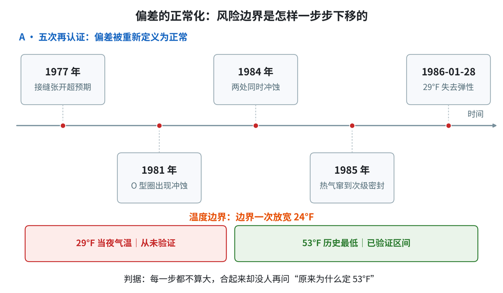

- **是什么**：把偏离设计预期的异常，一次次重新认证为“可接受风险”
- **为什么**：每次都没出事，“没出事”被当成“安全”的证据——归纳的误用
- **怎么判断**：三个信号——“以前也这样”、一次放宽很多、反对者被边缘化
- 五次放宽：1977 → 1981 → 1984 → 1985 → 1986 发射，每次都没出事
- 硬证据：历史最低密封温度 53°F，发射夜预报 29°F，**一次放宽 24°F**
- 一句话：每一次“再宽一点”，都让下一次更不可能被拒绝

## 挑战者号的三框架分析

- **后果论**：管理层算“发射收益 vs 延期成本”，把失效概率估计压到可接受；但概率估计被政治化（工程师估 1/100，对外宣称 1/100000）
- **义务论**：工程师的义务是如实报告并阻止发射；“摘掉工程师帽子”恰恰是要求放弃义务
- **美德伦理**：Boisjoly 的诚实（书面记录）与勇气（坚持反对）；组织对他的孤立说明美德需要制度保护
- **组织层面**：不是“坏人做坏事”，而是“**结构性压力让好人也说 yes**”
- 三框架同时指向的改进：**吹哨人机制 + 书面记录 + 独立安全通道**

## 案例：Citicorp 大楼风荷载

- 1977 年建成，纽约，**59 层**；底部四根柱子位于边中点而非四角，靠斜撑转换传力
- 1978 年 6 月，结构工程师 LeMessurier 因一个学生提问，重新计算 **45° 斜风**荷载
- 发现：原计算只考虑了垂直风向；斜风下连接节点应力大幅上升；施工时**螺栓连接替代了原设计的焊接**
- 结论：约 **16 年一遇**的大风即可导致节点破坏，进而连续倒塌
- 行动：立即报告业主；夜间焊接加固约 **3 个月**；准备**周边街区**的疏散预案；期间飓风 Ella 逼近但转向
- 1995 年真相公开；LeMessurier 被工程界视为职业责任的正例

## Citicorp 的伦理判断

- **后果论**：公开会带来巨大经济损失与恐慌；隐瞒会带来灾难 → 选择“公开 + 加固”，把期望损失降到最小
- **义务论**：工程师有义务告知业主与公众风险；不告知即欺骗
- **美德伦理**：诚实（承认自己设计的错误）、勇气（承担后果）、追求卓越（重新计算到底）
- **关键动作**：主动报告 → 独立复核 → 可执行的补救方案 → 对外沟通预案
- 与凯悦的对照：同样面对“变更/错误”，一个主动报告并修复，一个推责与隐瞒
- 一句话：**职业责任不是不出错，而是出错后第一反应是报告**

## 案例：波音 737 MAX（2018–2019）

- 2018 年 10 月 29 日，狮航 JT610 从雅加达起飞 12 分钟坠海，**189 人**遇难
- 2019 年 3 月 10 日，埃航 ET302 起飞 6 分钟坠毁，**157 人**遇难
- 两起共 **346 人**遇难；2019 年 3 月 13 日全球停飞，2020 年 1 月停产
- 直接原因：MCAS 依据**单一迎角传感器**数据，反复自动压低机头；飞行员未受充分训练
- 深层原因：为与 A320neo 竞争而快速改型；FAA 将部分安全评估**委托波音（ODA）**
- 后果：2021 年 1 月与美国司法部达成 **25 亿美元**和解（刑事罚金 2.436 亿、航司赔偿 17.7 亿、受害者基金 5 亿）

## 737 MAX 的三框架分析

- **后果论**：把“每架成本与上市时间”当主要变量，把生命折成“预期赔偿”——算术没错，但输入被组织目标污染
- **义务论**：对适航规章的义务、对乘客知情同意的义务，被“监管外包”架空
- **美德伦理**：内部邮件嘲讽安全文化，是职业美德的反面；正直与勇气在组织内被系统性削弱
- **组织层面**：**功能性理性**——把安全问题转化为“成本与进度”问题（第 9 讲展开）
- 与凯悦的共性：变更/简化 → 未回到独立复核 → 组织压力压过工程判断
- 结论：**安全不是合规的副产品，合规也不能外包给被监管者自己**

## 组织压力下的判断：四条行动线

1. **留下书面记录**：把风险、依据、时间写清楚（义务论要求可核查，美德论要求诚实）
2. **走完内部通道**：先向直接上级，再向上级管理者，逐级书面报告
3. **引用准则与法规**：把“我不同意”翻译成“准则第 X 条要求/法规第 X 条禁止”
4. **保留外部通道**：判断被否决且危及安全时，按 NSPE II.1.a 通知主管机关

> 四条行动线的共同前提：**在事情还没发生时就开始做**——事后再补记录，没人会信。

## 伦理推理的三种常见错误

- **相对主义**：“当地就这样”“行业惯例如此”——惯例能解释行为，不能证明正当
- **合理化**：先有结论再找理由（“大家都这么干”“不这么做公司会垮”）
- 合理化的变体是**偏差正常化**：把每次异常重新认证为“可接受”，边界逐步放宽
- **服从权威**：米尔格拉姆实验（1961—1963），约 65% 的被试在指令下施加到最高电压
- 另外两种：混淆事实与价值（从“能做到”推出“应该做”）；诉诸效率（把“不经济”当“不应该”）
- 共同结构：**先有结论，再找理由**；纠正靠“先写理由，再看结论”
- 一句话：**伦理推理的错误，多半是顺序错了**

## 伦理决策的记录与可辩护性

- 记六项：事实与来源、备选方案、判据与框架、结论与理由、残余风险、复核与批准
- 为什么要记：可核查（义务论）、可学习（组织记忆）、可自保（调查中唯一的证据）
- **公开检验**：如果当事人、监管者与媒体看到这份记录，你还站得住吗
- **角色互换**：如果被这样对待的是你或你的家人，你接受吗
- **时间检验**：十年后回看，这个理由还成立吗
- 形式要求：与设计文件同级管理——版本、日期、签署、归档年限
- 反面清单：口头同意、会后补记、“大家心里都清楚”
- 一句话：**没有记录的决定，在事故调查里等于没做过**

## 工程伦理与法律：合法不等于正当

- 法律：最低要求、普遍适用、有强制力；伦理：更高要求、情境判断、靠共同体与良心
- 四象限：合法且正当／合法但不正当／违法但可能正当（公民不服从）／违法且不正当
- 历史证据：童工与奴隶制曾合法，且以“经济效率”为其辩护
- 合规不等于安全：737 MAX 通过适航认证；凯悦的变更图纸也盖了章
- 法律滞后于技术：算法、数据与自动化的责任规则仍在形成
- 工程师的双重身份：法律上的行为责任人，同时是职业共同体的成员
- 实践原则：**以法律为下限，以准则为中线，以伦理为上限**
- 一句话：**法律划线，伦理问这条线画得对不对**

## 三层次×三框架：一张总图

| 层次 | 义务论 | 后果论 | 德性论 |
| --- | --- | --- | --- |
| 禁止性 | 不欺骗、不伪造、不越权签字 | 不制造不可接受的风险 | 不做违心的执行者 |
| 预防性 | 复核、留痕、逐级上报 | FMEA、风险—收益、预警阈值 | 敢说“不”、敢报告 |
| 志向性 | 主动告知超出职责的风险 | 主动寻找更安全的替代 | 把公共利益放进职业理想 |
| 责任类型 | 法律与角色责任 | 角色与道德责任 | 道德责任（含超义务） |

- 横向读是层次，纵向读是框架，**交叉处就是要写下的那句理由**
- 每一格都能改写成一句追问：这一步允许吗？防住了吗？像我会做的事吗？
- 三个层次不是三个档次，而是同一职业的三层要求：底线、防线、天花板
- 一句话：**底线靠守，防线靠建，志向靠养**

## 课堂辩论题与评分点

- 辩题一：工期与安全冲突时，工程师是否应拥有“一票否决权”
- 辩题二：把在本国不可接受的风险出口到标准较低的国家，是否允许
- 辩题三：算法造成的歧视，责任应由开发者、部署方还是使用者承担
- 规则：立论 3 分钟、质询 4 分钟、结辩 2 分钟；每方至少引用一条准则或一个案例事实

| 评分维度 | 权重 | 看什么 |
| --- | --- | --- |
| 事实准确性 | 30% | 数据、条款、案例细节不出错 |
| 框架使用 | 30% | 三框架至少用两个，且用对 |
| 回应质量 | 20% | 正面回答对方最强论点 |
| 方案可执行 | 20% | 谁做、何时做、留什么证据 |

- 扣分项：只讲立场不讲理由；空喊“安全第一”而不给方案
- 一句话：辩论不是说服对方，是**让第三方听懂你的理由**

## 本部分小结：四件工具与三句话

- 四件工具：三分解（事实／概念／规范）、划线法、创造性中间道路、六步法
- 三框架一句话：后果论算总账、义务论守底线、德性论看品格
- 两个补充视角：权利论问“谁的权利被侵犯”，关怀伦理问“关系是否被维系”
- 六个演练场景的共性：压力来自进度、成本与上级，**不来自技术本身**
- 分歧时怎么办：先看是否收敛；不收敛则底线优先，并写下取舍理由
- 决策的终点是记录：可公开、可互换、可经时间检验
- 一句话：**伦理能力＝把直觉翻译成理由的能力**

## 伦理决策复习与练习

- 复习一：三类问题各举一例，并说明各自靠什么解决
- 复习二：写出功利主义的三步计算法，并指出它的两个局限
- 复习三：用定言令式的两个形式，分析“隐瞒已知缺陷”为何不可
- 复习四：说明划线法里“权重”与“计数”的区别，各举一例
- 练习一：选一个实习或实验室场景，按六步法写一页决策记录
- 练习二：为“算法歧视”案例设计三条可执行措施，并给出验证指标
- 练习三：找一条你所在单位的规章，判断它属于“合法且正当”还是“合法但不正当”
- 提交要求：一页 A4，含事实来源、所用框架、结论与残余风险

## 推导留给 AI：伦理决策框架（汇总）

- 用三框架分别分析“工期压缩导致试验周期减半”，写出每框架的结论与理由。
- 挑战者号中，管理层的“摘掉工程师帽子”在义务论与美德伦理下分别错在哪里？
- Citicorp 案例中，LeMessurier 的哪些动作属于“义务”，哪些属于“超义务”？
- 为 737 MAX 设计一条“监管不外包”的制度，说明它如何防止 MCAS 这类单点依赖。

# 第五部分 · 例题、讨论与 AI 提问

- 例题 1：凯悦连接荷载复核（定量）
- 例题 2：三框架分析一个技术变更
- 例题 3：职业准则条款匹配
- 课堂讨论：Brad 的图纸、谁有权叫停、开放问题

## 真题视角：伦理题怎么考

- 2020—2022 三届试卷**未直接出伦理题**；但两类题会用到本讲：
  - **判断题**：安全事故 vs 安全责任事故、责任判定（第 9 讲）
  - **论述题**：题干常要求“结合案例”，凯悦、737 MAX 是现成素材
- **预测题**（论述风格）：结合凯悦案，论述“工程师的责任边界”——三步作答：
  1. 事实链（变更—复核—签章）
  2. 可预见性／可控制性分析
  3. 结论：责任跟着签章与最终把关走
- 提醒：伦理题不给“感想分”，给的是概念准确 + 案例事实 + 判断有依据

## 例题 1：凯悦连接荷载复核

**求**：（1）原设计安全系数；（2）变更后安全系数；（3）若要保持 1.5 倍安全系数，承载力应提高到多少？

解答

$$K_{\text{原}}=\frac{133}{89}=1.49,\qquad K_{\text{变更}}=\frac{133}{178}=0.75,\qquad F_{\text{需}}=1.5\times 178=267\ \text{kN}$$

- 变更后安全系数 $0.75<1$，在设计荷载下即已破坏
- 要把安全系数恢复到 1.5，连接承载力需由 133 kN 提高到 **267 kN**，即增加约 **101%**
- 结论：变更后**没有任何可行的局部补强**，必须重新设计连接节点

## 例题 2：三框架分析一个技术变更

**情形**：某型号电机定子线径由 1.0 mm 改为 0.9 mm，可省 6% 成本、每台减重 0.3 kg；但温升提高 8 K，绝缘寿命估计由 12 年降到 8 年。客户不知情，销售仍按“12 年寿命”宣传。

| 框架 | 分析要点 | 结论 |
| --- | --- | --- |
| 后果论 | 算企业收益（6% 成本）与用户损失（提前更换、索赔、品牌） | 长期净损失大于短期收益 |
| 义务论 | 宣传与实物不符即欺骗；客户知情同意被剥夺 | 不可交付 |
| 美德伦理 | 诚实要求改回或改宣传；卓越要求不满足于“能用” | 两条可行动路径 |

- **可行动方案**：① 改回线径；② 保留变更但重做寿命试验并如实告知客户
- 三框架一致结论：**不能按原宣传交付**

## 例题 3：职业准则条款匹配

| # | 行为 | 对应条款 |
| --- | --- | --- |
| ① | 未做型式试验即签署试验报告 | II.1.b（只批准合规文件）、II.3.a（真实陈述） |
| ② | 工期紧，用经验估算替代计算书 | II.2（胜任要求）、II.1.b |
| ③ | 接受供应商免费考察后指定其产品 | II.4.a（披露利益冲突）、II.5（避免欺骗） |
| ④ | 发现同组图纸有错，怕影响考核不报 | II.1.a、II.1.f ＋ 美德：勇气 |
| ⑤ | 用公司设备与工时接私活 | III.6.c（不得用雇主资源私自执业） |

- 匹配的关键不是背编号，而是先问：**这条义务的对象是谁**（公众、雇主、同行、职业）

## 课堂讨论与开放问题

**讨论 1**：Brad 的图纸被直接盖章送给承包商，他多次反映无果。他该怎么做？（提示：NSPE II.1.a、II.2；台湾工程师信条“敬业守分”）

**讨论 2**：如果你在凯悦案中是绘图员，发现变更后荷载翻倍，你会向谁报告？按什么顺序？

**讨论 3**：Citicorp 的做法能复制到你的课题组吗？谁有权叫停一个“看起来没问题”的方案？

**讨论 4（开放）**：如果举报会导致团队解散、项目终止、自己被边缘化，你还举报吗？请给出你的三条底线。

## 历年真题：本讲（伦理）考查方式与分值

- 六卷＝2020—2022 三届 A／B 卷；题型：单选 30＋简答 30＋论述 30＋计算 10
- **直接伦理题 0 分**：不考背名词，考“往论述题里嵌”——伦理是论据库与判据库

| 考法 | 载体 | 分值 | 说明 |
| --- | --- | --- | --- |
| 直接题 | 2020—2022 六卷 | 0 | 六卷均无直接命题 |
| 相邻题 | 六卷全有 | 3 | 法人责任：个人独资无限 |
| 论述题 | 六卷各 3 题 | 10／题 | 凯悦、737 MAX 是素材 |
| 课程设计 | 教学计划 | 计入成绩 | 伦理与社会影响独立一章 |

- 若考“结合案例”，凯悦、挑战者号、737 MAX 三选一，不堆砌
- 得分看三样：概念准确、事实具体（时间／数字／条款）、判断有依据；不给“感想分”，空话套话一律低分
- 优先级：凯悦事实链＞三框架＞NSPE 六条；别把时间花在背名词上

## 案例论述题答题模板（事实-冲突-框架-结论-措施）

- 适用：10 分论述题（“结合案例，论述……的责任／能不能做／如何改进”）
- 五段不是五段话，是五个**得分动作**；每段首句先给判断，再给证据：

| 段落（分值） | 写什么 | 句式 |
| --- | --- | --- |
| 事实（2 分） | 时间、地点、主体、变更、后果；只写可核查的 | “×年×月，×方在×环节做了×变更，导致×后果” |
| 冲突（2 分） | 2–3 组价值冲突＋利益相关方 | “一方要……，另一方要……；受影响的是……” |
| 框架（3 分） | 三框架各 1 分；每框架＝判据＋本案应用 | “按义务论……；按后果论……；按美德论……” |
| 结论（1 分） | 一句话判断：谁负责／能不能做 | “因此，……应负主要责任／该方案不可交付” |
| 措施（2 分） | 3 条，动词开头，含主体／时限／记录 | “①……；②……；③……” |

- 时间：15 分钟／450 字；事实 3 分钟、冲突 3 分钟、框架 5 分钟、结论＋措施 4 分钟
- 高分特征：每个判断后跟一个事实或条款；措施能落到“谁、何时、留下什么”
- 低分特征：通篇“我认为／应该加强”；框架只贴标签；事实与评价混写
- 一句话：模板不是填空，是逼你把“感觉”翻译成“证据”

## 真题模拟：凯悦案的伦理分析（完整示范）

**题目**：结合凯悦酒店天桥坍塌案，论述工程师的责任边界。（10 分）

**事实（2 分）** 1981 年 7 月 17 日 19 时 05 分，堪萨斯城凯悦酒店 4 楼走道坠落砸中 2 楼，114 人死亡、216 人受伤；吊杆由一根通长改为两根，4 楼连接荷载 89→178 kN，承载力 133 kN，$K=0.75$；改图盖设计方印章。

**冲突（2 分）** 公众安全被工期与施工便利挤压；设计方把关被分包商自主削弱；监督义务被省现场服务费架空；公众知情与组织忠诚对立。

**框架（3 分）** 义务论：NSPE I.1 公众优先、II.1.b 只批合规文件，盖章即承诺复核；后果论：省下的施工便利远小于 114 人死亡、216 人受伤、约 1.4 亿美元与吊销执照；美德论：诚实、勇气、追求卓越。

**结论（1 分）** 设计方负主要责任——责任跟着签章与最终把关走，不跟着“谁提出变更”走；未复核是直接缺口，1979 年前兆未查是加重情节。

**措施（2 分）** ① 变更回算＋独立复核（ECN），口头通知 24 小时内补书面；② 设驻场设计代表，前兆查全结构；③ 危及安全时按 II.1.a 上报。

- 得分点 2＋2＋3＋1＋2；约 450 字；事实不夹评价，措施不写口号

## 真题模拟：吹哨问题的判断

**模拟题（10 分）** 协作机器人企业赶订单，安全限速上调 60% 未重评，已 OTA 推给 3 家客户；经理称“参数合规”，你已口头反对。是否吹哨？

| # | DeGeorge 条件 | 本案事实 | 判断 |
| --- | --- | --- | --- |
| ① | 危害严重且可预见 | 人机协作，超速可致伤 | 满足：可预见人身伤害 |
| ② | 已向直接上级报告 | 仅一次口头反对 | 部分：需补书面 |
| ③ | 穷尽内部渠道 | 未报安全负责人 | 不满足：还差两级 |
| ④ | 有可说服的证据 | 有参数记录，缺风险评估 | 部分：补对比试验 |
| ⑤ | 公开能阻止危害 | OTA 可回滚、可召回 | 满足：能迅速降险 |

- **结论**：现在不能对外吹哨——先书面报告＋要求暂停出货＋提交回滚方案，限 7 日内书面答复
- 仍不处理且危害持续：按 NSPE II.1.a 通知主管机关；紧迫且内部无效可先止损再补程序并留痕
- **Davis 共谋论**：理由不止“防止伤害”，还有“不参与错事”；无须先证明公开奏效，但须有正当理由相信组织在做严重错事

## 课堂讨论：工程师该听谁的（雇主/公众/准则）

**情境**：客户要求下周交付，你发现某安全参数按规范应复测；复测要延期，项目经理说“先发货，下批再补”。你听谁的？

- 先把“该听谁”拆成三方主张：雇主给指令，公众承担风险，准则给判据

| 对象 | 它的要求 | 依据 | 边界 |
| --- | --- | --- | --- |
| 雇主 | 按合同、按指令、按进度交付 | NSPE II.4 忠实代理人 | 违法或危及公众的指令不是义务 |
| 公众 | 安全、健康、福祉优先；有权知情 | NSPE I.1；执照由公众授予 | “公众”要落到具体受影响群体 |
| 准则 | 按成文条款判断、留痕、可核查 | 职业共同体自律；三套准则 | 准则不是法律，条款有解释空间 |

- 不是“三选一”：日常听雇主，底线听准则，冲突时公众安全优先
- 双重忠诚：对组织与对职业；批判性忠诚＝在职业伦理约束内照顾雇主利益
- 行动顺序：先说服→再升级→最后拒绝／举报；每一步留书面记录
- 讨论：项目经理的“下批再补”能替代本次复测吗？如果不能，延期由谁承担？

## 课堂讨论：合规但缺德的事能不能做

- 问题不是“违不违法”，而是“法律没管到的地方，工程师凭什么说不”

| 情形 | 合伦理 | 不合伦理 |
| --- | --- | --- |
| 合规 | 可以做，也可以做得更好 | **本页焦点**：合法但有可预见伤害或未告知 |
| 不合规 | 通常不能做；例外须经正当性论证 | 不能做 |

- Citicorp：满足纽约市 90° 风荷载规范，LeMessurier 仍重算 45° 斜风、主动加固——“规范不能为所有情形设定可靠的照顾标准”
- 三条判据：① 伤害是否可预见 ② 受影响者是否知情同意 ③ 是否利用标准滞后与信息不对称
- 结论：合规是底线，不是上限；“能做”是法律许可，“该做”是职业判断；不能用合规当挡箭牌隐瞒已知风险
- 边界：不能把“我觉得不安全”当否决权，须有计算、试验、同行复核

## 课堂辩论：安全投入与经济性的冲突

**辩题**：安全投入应不应该“不计成本”？正方“生命无价”，反方“资源有限、按风险排序”。

| 立场 | 核心论点 | 最强证据 | 软肋 |
| --- | --- | --- | --- |
| 正方 | 生命无价，事故代价不可逆 | 凯悦的两次“省”：审查范围只到屋顶、三次拒绝现场代表 | 答不出“投多少才够”；挤出其他安全投入 |
| 反方 | 资源有限，安全投入边际收益递减 | ALARP：风险降到合理可行最低 | “可接受”由谁定；容易变成“可接受给谁” |

- 真正分歧不是“要不要安全”，而是“风险降到哪、谁来决定、证据是什么”
- 三条判准：ALARP（合理可行最低）、可接受风险（知情同意）、程序正义（受影响者参与）
- 凯悦的教训不是“没花钱”，而是“省钱的决定没有回到安全评估”
- 投票：用 1 亿元把风险从 $10^{-6}$ 降到 $10^{-7}$，你接受吗？先问这 1 亿元挤掉了什么

## 简答模板：职业伦理/责任/准则各答三段

- 5 分简答只写三段：**定义—要点—例证**；每段首句是判断句，例证只举一个

| 题型 | 第一段：定义 | 第二段：要点 | 第三段：例证 |
| --- | --- | --- | --- |
| 职业伦理 | 知识不对称＋专业七项特征 | 公众优先、胜任、诚实、避免冲突、保密 | 凯悦盖章／Citicorp 主动报告 |
| 责任 | 因果／角色／法律／道德 | 可预见性＋可控制性；签章即责任；监督责任 | 凯悦 G.C.E.／737 MAX 监管外包 |
| 准则 | 总则＋六条＋执业规则 | I.1 压倒性；II.1.a／b；II.4.a 披露冲突 | Brad 图纸／凯悦 II.1.b |

- 三段比例 1∶3∶1；150–200 字；先给结论再展开，不要“总—分—总”绕圈
- 例证要有时间、主体、数字；宁缺毋滥，一个例子讲透胜过三个例子并列
- 常见扣分：只背条款不解释；例证与论点不对应；把“责任”写成“职责”清单

## AI 提问：本讲 5 个延伸问题

- 把 AI 当助教，不当答案机：每题都要求它给条款、数字、反例，并标注“需查证”
1. **复核计算**：输入凯悦 89／178／133 kN，要求列公式、单位、三个可拦截节点；检查它是否把 $K=0.75$ 说成“接近安全”
2. **角色模拟**：让 AI 扮演 NSPE 伦理委员会，写 300 字裁决，必须引用 I.1、II.1.b，并区分四种责任；核对条款是否编造
3. **场景迁移**：让 AI 给三个“合规但可能不安全”的智能制造场景（OTA 升级、协作机器人限速、安全联锁旁路），每个给判据与反例
4. **理论对照**：让 AI 比较 DeGeorge 与 Davis 的吹哨条件，套一个中国工厂情境，指出两理论结论不同的那一步
5. **反方训练**：让 AI 站在反方，为“安全投入应设上限”找最强论据，并给一条可核查判准；只给口号就重写
- 验收标准：有条款、有数字、有反例、有不确定性标注；四样缺一，答案退回

## 考前自测：10 道判断题

- **1** 凯悦变更后连接安全系数降到 0.75。
- **2** 变更由施工方提出，设计方即可免责。
- **3** NSPE 第一条要求公众安全、健康、福祉优先。
- **4** 通过法定检验即可免除伦理责任。
- **5** NSPE 要求工程师只在胜任领域执业。
- **6** 偏差正常化指把未出事的违规当成标准。
- **7** 吹哨的第一步应直接联系媒体。
- **8** 后果论只需计算企业自身收益。
- **9** 合规是伦理的底线，不是全部。
- **10** 工程师只需对自己亲手做的事负责。
- 答案：1√ 2× 3√ 4× 5√ 6√ 7× 8× 9√ 10×
- 易错 4、8（把合规当免责、把后果论算成企业账）与 2、10（责任跟着签章与监督走）

# 第六部分 · 本讲小结、作业与下讲预告

- 本讲小结：工程是社会实验、凯悦事故链、三套准则、三框架
- 作业 4 题：事故链复述、荷载计算、三框架分析、8D 与责任闭环
- 下讲预告：工程风险的来源与评估、安全事故与安全责任事故、工程师与组织、信任
- 课后：用三步框架为课程设计写一页伦理与社会影响分析

## 本讲小结：社会性、职业责任、决策框架

1. **社会性**：技术后果经社会放大——桥梁一个连接、飞机一个传感器，都会成为公共事件；只有“可预见且可控制”的后果，才落在职业责任边界内。
2. **职业责任**：三套准则把“公众安全优先”写成条款；责任跟着签章、复核与最终把关走，不跟着职位高低走。
3. **决策框架**：先拆事实与概念，用划线法和中间道路找方案，再以义务论排底线、后果论排次序、美德论排自我要求，最后把理由写下来。
- 四块内容：社会性与事故代价 → 凯悦事故链 → 三套准则 → 三框架与案例
- 一个剧本：变更或简化 → 未回到独立复核 → 组织压力压过工程判断
- 一条判据：能说清“谁受影响、受多大、我凭什么”，才叫伦理判断
- 90 秒自测：合上讲义复述三句话，各配一例（凯悦／切尔诺贝利／737 MAX）

## 关键概念清单：20 个术语

| 组 | 4 个术语 | 一句话 |
| --- | --- | --- |
| 社会与事故 | 社会实验、隐含社会契约、可预见性、事故链 | 定边界 |
| 责任与制度 | 四种责任、照顾标准、负责监督、组织原因 | 定归属 |
| 准则与职业 | NSPE 六条、胜任领域、利益冲突、吹哨 | 定底线 |
| 框架与方法 | 划线法、创造性中间道路、后果论、义务论 | 定推理 |
| 层次与品格 | 美德伦理、三层次、道德能动性、超义务 | 定上限 |

- 会辨析三对：可预见性／可控制性、过失／合规、角色责任／道德责任
- 会背三条：公众安全优先；只在胜任领域执业；被否决且危及安全时通知主管机关，并留痕
- 抽查：下次课随机抽 5 个术语，各配一句定义与一个本讲案例中的事实

## 作业：概念、案例分析与伦理推理（100 分）

**一、概念（20 分）**：任选 10 个术语，各写一句定义＋一个本讲事实；再辨析三对易混概念（可预见性／可控制性、过失／合规、角色责任／道德责任），每对 4 分；所有定义须能落到具体条款或事实。

**二、案例分析（40 分）**：300 字复述凯悦事故链（15 分）；标三个可拦截节点并各配一条制度（15 分）；答“若有独立复核，最小割集在哪”（10 分）。

**三、伦理推理（40 分）**：自选可查证案例，用后果论、义务论、美德伦理各写 3 条（25 分）；说明结论是否一致及排序依据（15 分）。

- 提交：A4／PDF，下次课前；案例注明来源（判决书、调查报告、标准原文）
- 选题：本专业近十年公开事故、召回或行政处罚
- 评分：事实具体＋依据可查（条款／公式）＋给出替代方案
- 互评：两人交换事实链，按“时间、部位、数字、依据”打分

## 下讲预告：风险、安全与组织伦理

**第 9 讲 2 课时**：从“事故已经发生”转到“风险如何被识别、分配与汇报”。

| 内容块 | 主线 | 落点 |
| --- | --- | --- |
| 1 | 风险来源与可接受风险 | 技术／人为／外部环境三类来源；没有零风险，只有安全等级 |
| 2 | 安全事故与安全责任事故 | 责任判定与《建设工程安全生产管理条例》的责任划分 |
| 3 | 工程师与组织 | 职业矛盾与交流矛盾、功能性理性、责任模糊化 |
| 4 | 健康组织文化与信任 | 八条做法、吹哨三条件、信任的建立与修复 |

- 预习问题：你所在的实验室或实习单位，上一次“坏消息”是怎么被汇报上来的？
- 与课程设计接口：风险清单与“谁有权叫停”，直接写进伦理分析章的第二步

## 课后阅读与预习清单（Harris 第 2、3、6 章）

| 章节 | 主要内容 | 页码与读法 |
| --- | --- | --- |
| 第 2 章 | A Practical Ethics Toolkit：事实、概念、划线法、创造性中间道路 | p24–49，通读 §2.2–2.9 |
| 第 3 章 | Responsibility in Engineering：照顾标准、负责监督、多手问题 | p51–70，精读 §3.2–3.7、§3.11 |
| 第 6 章 | Risk and Liability in Engineering：风险、风险沟通、侵权责任 | p107–135，精读 §6.2–6.6 |

- 中文材料：2020 年《工程与社会》课件“伦理学基本方法”“工程伦理-工程事故”两讲，对照术语差异
- 选读：第 5 章 Trust and Reliability（p90–106），为第 9 讲“信任”一节做准备
- 提交：1 页阅读笔记（每章 1 条要点＋1 个疑问），下次课带来
- 预习第 9 讲：带一个你亲历或听说的“差点出事”的现场细节

## 伦理案例写作要求：课程设计伦理章预告

**课程设计中的伦理分析章按三步框架写，案例写作是它的最小单元。**

| 步 | 写什么 | 证据要求 |
| --- | --- | --- |
| 一 | **利益相关方**：列名单（用户、操作工、维修工、下游客户、监管）并写清影响 | 影响要量化或可核查 |
| 二 | **问题定位**：归入安全、隐私、公平、环境四类，指出最严重的一类 | 对应准则条款或法规条文 |
| 三 | **决策与辩护**：至少两个备选方案，用原则支持选择，回应最强反对 | 数据、标准、事故调查报告 |

- 篇幅：案例 1500 字以内；结构＝事实—问题—分析—方案—反驳—结论
- 常见错误：写成感想、只批评企业不给替代方案、把“合规”当“无过错”
- 与第 8 讲接口：凯悦事故链是“事实”部分的范例，737 MAX 是“组织压力”部分的范例

## 期末复习提示：案例论述题怎么答

**试卷结构（以智造 2021 A 卷为例）**：单项选择 30＋分析简答 30＋论述与计算 40。

| 题型 | 分值 | 本讲落点 | 答法 |
| --- | --- | --- | --- |
| 单选 | 30 | 术语辨析：社会实验、照顾标准、三框架 | 认定义，不展开 |
| 简答 | 30 | 准则条款匹配、责任类型判断 | 一句判断＋一条依据 |
| 论述 | 30 | “结合案例”谈责任边界、组织压力 | 事实链→分析→结论 |
| 计算 | 10 | 安全系数、连接荷载复核 | 公式＋代入＋单位 |

- 论述题五步骨架：事实链、受影响方、准则或框架、替代方案、结论与条件
- 2020—2022 三届未直接出伦理题，但伦理是判断题与论述题的分析工具
- 失分点：只写感想、堆术语不落案例、结论无依据；得分点全在“可核查”

## 本讲重点回顾与考试提示

**四个必会**

1. 事故链：时间、结构部位、变更、复核、签章——缺一环就说不清责任
2. 荷载复核：安全系数＝承载力／荷载，凯悦案由 $133/89=1.49$ 降到 $133/178=0.75$
3. 四类责任：因果、角色、法律、道德，四张网不同步，合法不等于无责
4. 三框架：义务论排底线、后果论排次序、美德论排自我要求

**三句必背**

- 工程是社会实验，责任边界＝可预见 × 可控制
- 责任跟着签章与最终把关走，不跟着职位高低走
- 技术能力决定你能不能做，伦理判断决定你该不该做
- 考试提示：先给事实（时间、部位、数字），再给判断，最后给依据；不写感想，不堆术语